# Práctica computacional guiada: análisis exploratorio, correlación, ACP y Biplot

Métodos Estadísticos Avanzados 1 — código, resultados, interpretación y preguntas de análisis

# 1 Propósito de la práctica

Esta práctica reorganiza en una sola secuencia los procedimientos de análisis descriptivo, correlación, análisis de componentes principales (ACP/PCA) y Biplot. La lógica de trabajo será:

$$\text{datos}\rightarrow\text{descripción univariada}\rightarrow
\text{relaciones bivariadas}\rightarrow\text{correlación}\rightarrow
\text{ACP}\rightarrow\text{Biplot}.$$

El conjunto principal será `MASS::Cars93`. Al final se incluyen dos extensiones breves con `iris` y `USArrests` para comprobar que el procedimiento se generaliza a otros contextos.

El objetivo no es únicamente obtener gráficos. Se busca interpretar qué información conserva cada procedimiento, qué supuestos o decisiones intervienen y qué conclusiones son razonables a partir de los resultados.

# 2 1. Preparación del entorno

## 2.1 1.1. Paquetes requeridos

El documento **no instala paquetes automáticamente**. La instalación se realiza una sola vez en cada computador. Si falta alguno, R detendrá la compilación e indicará cuáles deben instalarse.

# 3 2. Práctica I: análisis descriptivo de `Cars93`

## 3.1 2.1. Carga y selección de variables

`Cars93` contiene información de 93 automóviles comercializados en Estados Unidos en 1993. La base completa posee 27 variables. Para evitar una práctica innecesariamente extensa, se seleccionan cinco variables categóricas y seis variables numéricas que permiten estudiar precio, eficiencia, tamaño y potencia.

```r
# Carga explícitamente Cars93 desde el paquete MASS.
data("Cars93", package = "MASS")

# Copia la base y convierte los nombres de las columnas a snake_case.
datos_originales <- MASS::Cars93 |>
  janitor::clean_names()

# Guarda el número original de observaciones para documentar posibles eliminaciones.
n_original <- nrow(datos_originales)

# Define las variables categóricas que se analizarán.
variables_categoricas <- c(
  "type",
  "drive_train",
  "air_bags",
  "origin",
  "man_trans_avail"
)

# Define las variables numéricas que se analizarán y que posteriormente entrarán al ACP.
variables_numericas <- c(
  "price",
  "mpg_city",
  "mpg_highway",
  "engine_size",
  "horsepower",
  "weight"
)

# Crea etiquetas en español para utilizar en tablas, gráficos e interpretaciones.
etiquetas_numericas <- c(
  price = "Precio",
  mpg_city = "Rendimiento en ciudad",
  mpg_highway = "Rendimiento en carretera",
  engine_size = "Tamaño del motor",
  horsepower = "Potencia",
  weight = "Peso"
)

# Crea etiquetas en español para las variables categóricas.
etiquetas_categoricas <- c(
  type = "Tipo de automóvil",
  drive_train = "Sistema de tracción",
  air_bags = "Bolsas de aire",
  origin = "Origen",
  man_trans_avail = "Transmisión manual disponible"
)

# Selecciona identificadores, variables categóricas y variables numéricas de interés.
datos <- datos_originales |>
  dplyr::select(
    manufacturer,
    model,
    dplyr::all_of(variables_categoricas),
    dplyr::all_of(variables_numericas)
  )

# Convierte de manera explícita las variables categóricas en factores.
datos <- datos |>
  dplyr::mutate(
    dplyr::across(
      dplyr::all_of(variables_categoricas),
      as.factor
    )
  )

# Cuenta los valores faltantes antes de decidir cómo tratarlos.
faltantes_por_variable <- colSums(is.na(datos))

# Muestra el conteo de valores faltantes por variable.
faltantes_por_variable
```

```
##    manufacturer           model            type     drive_train        air_bags
##               0               0               0               0               0
##          origin man_trans_avail           price        mpg_city     mpg_highway
##               0               0               0               0               0
##     engine_size      horsepower          weight
##               0               0               0
```

```r
# Identifica las filas completas únicamente respecto a las variables utilizadas en la práctica.
filas_completas <- complete.cases(datos)

# Conserva una única muestra analítica para toda la práctica.
datos <- datos[filas_completas, , drop = FALSE]

# Guarda el número final de observaciones utilizadas.
n_final <- nrow(datos)

# Calcula cuántas observaciones fueron excluidas por información incompleta.
n_eliminadas <- n_original - n_final

# Muestra las dimensiones de la muestra analítica final.
dim(datos)
```

```
## [1] 93 13
```

```r
# Muestra la estructura para verificar los tipos de las variables.
str(datos)
```

```
## 'data.frame':    93 obs. of  13 variables:
##  $ manufacturer   : Factor w/ 32 levels "Acura","Audi",..: 1 1 2 2 3 4 4 4 4 5 ...
##  $ model          : Factor w/ 93 levels "100","190E","240",..: 49 56 9 1 6 24 54 74 73 35 ...
##  $ type           : Factor w/ 6 levels "Compact","Large",..: 4 3 1 3 3 3 2 2 3 2 ...
##  $ drive_train    : Factor w/ 3 levels "4WD","Front",..: 2 2 2 2 3 2 2 3 2 2 ...
##  $ air_bags       : Factor w/ 3 levels "Driver & Passenger",..: 3 1 2 1 2 2 2 2 2 2 ...
##  $ origin         : Factor w/ 2 levels "USA","non-USA": 2 2 2 2 2 1 1 1 1 1 ...
##  $ man_trans_avail: Factor w/ 2 levels "No","Yes": 2 2 2 2 2 1 1 1 1 1 ...
##  $ price          : num  15.9 33.9 29.1 37.7 30 15.7 20.8 23.7 26.3 34.7 ...
##  $ mpg_city       : int  25 18 20 19 22 22 19 16 19 16 ...
##  $ mpg_highway    : int  31 25 26 26 30 31 28 25 27 25 ...
##  $ engine_size    : num  1.8 3.2 2.8 2.8 3.5 2.2 3.8 5.7 3.8 4.9 ...
##  $ horsepower     : int  140 200 172 172 208 110 170 180 170 200 ...
##  $ weight         : int  2705 3560 3375 3405 3640 2880 3470 4105 3495 3620 ...
```

### 3.1.1 Análisis guiado de la carga y depuración

La primera pregunta de un análisis exploratorio no es “¿qué gráfico hago?”, sino **“¿qué datos estoy analizando realmente?”**. La base parte de 93 automóviles y la muestra analítica conserva 93; se excluyen 0 observaciones. El número total de celdas faltantes en las variables seleccionadas es 0. Las variables con al menos un faltante son: ninguna.

La salida de `str(datos)` debe usarse para verificar que las cinco variables cualitativas son factores y que precio, consumos, tamaño del motor, potencia y peso permanecen numéricas. Este control evita errores silenciosos: una variable categórica almacenada como número puede entrar indebidamente en medias, correlaciones o ACP.

**Qué debería escribir un estudiante en su informe.** Debe reportar el tamaño de la base original, el tamaño de la muestra final, el criterio usado para eliminar filas incompletas y si la pérdida de observaciones es suficientemente grande como para cuestionar la representatividad de la muestra.

> **Preguntas para resolver.** ¿La exclusión de 0 filas parece sustancial frente a 93? ¿Qué problema aparecería si el ACP se calculara con una muestra distinta de la utilizada en las correlaciones?

## 3.2 2.2. Distribuciones de las variables categóricas

Para una variable categórica interesa conocer la frecuencia absoluta

$$n_j=\#\{i:X_i=j\},$$

y la frecuencia relativa

$$f_j=\frac{n_j}{n}.$$

```r
# Selecciona solamente las variables categóricas de la muestra analítica.
datos_categoricos <- datos |>
  dplyr::select(dplyr::all_of(variables_categoricas))

# Recorre cada variable categórica para construir una tabla de frecuencias independiente.
tablas_categoricas <- purrr::map2(
  datos_categoricos,
  names(datos_categoricos),
  ~ {
    # Convierte la variable actual en un data frame con un nombre común.
    tabla_actual <- data.frame(categoria = .x)

    # Cuenta cuántas observaciones pertenecen a cada categoría.
    tabla_actual <- tabla_actual |>
      dplyr::count(categoria, name = "frecuencia_absoluta")

    # Calcula la frecuencia relativa y el porcentaje correspondiente.
    tabla_actual <- tabla_actual |>
      dplyr::mutate(
        frecuencia_relativa = frecuencia_absoluta / sum(frecuencia_absoluta),
        porcentaje = scales::percent(frecuencia_relativa, accuracy = 0.1)
      )

    # Añade el nombre legible de la variable categórica procesada.
    tabla_actual <- tabla_actual |>
      dplyr::mutate(variable = etiquetas_categoricas[[.y]], .before = 1)

    # Devuelve la tabla correspondiente a la variable actual.
    tabla_actual
  }
)

# Une las tablas individuales en una única tabla larga.
tabla_frecuencias_categoricas <- dplyr::bind_rows(tablas_categoricas)

# Identifica la categoría más frecuente dentro de cada variable categórica.
categorias_dominantes <- tabla_frecuencias_categoricas |>
  dplyr::group_by(variable) |>
  dplyr::slice_max(frecuencia_absoluta, n = 1, with_ties = FALSE) |>
  dplyr::ungroup()

# Identifica la categoría menos frecuente dentro de cada variable categórica.
categorias_minoritarias <- tabla_frecuencias_categoricas |>
  dplyr::group_by(variable) |>
  dplyr::slice_min(frecuencia_absoluta, n = 1, with_ties = FALSE) |>
  dplyr::ungroup()

# Presenta la tabla final dentro del documento.
knitr::kable(
  tabla_frecuencias_categoricas,
  caption = "Frecuencias de las variables categóricas"
)
```

Frecuencias de las variables categóricas

| variable | categoria | frecuencia_absoluta | frecuencia_relativa | porcentaje |
| --- | --- | --- | --- | --- |
| Tipo de automóvil | Compact | 16 | 0.1720430 | 17.2% |
| Tipo de automóvil | Large | 11 | 0.1182796 | 11.8% |
| Tipo de automóvil | Midsize | 22 | 0.2365591 | 23.7% |
| Tipo de automóvil | Small | 21 | 0.2258065 | 22.6% |
| Tipo de automóvil | Sporty | 14 | 0.1505376 | 15.1% |
| Tipo de automóvil | Van | 9 | 0.0967742 | 9.7% |
| Sistema de tracción | 4WD | 10 | 0.1075269 | 10.8% |
| Sistema de tracción | Front | 67 | 0.7204301 | 72.0% |
| Sistema de tracción | Rear | 16 | 0.1720430 | 17.2% |
| Bolsas de aire | Driver & Passenger | 16 | 0.1720430 | 17.2% |
| Bolsas de aire | Driver only | 43 | 0.4623656 | 46.2% |
| Bolsas de aire | None | 34 | 0.3655914 | 36.6% |
| Origen | USA | 48 | 0.5161290 | 51.6% |
| Origen | non-USA | 45 | 0.4838710 | 48.4% |
| Transmisión manual disponible | No | 32 | 0.3440860 | 34.4% |
| Transmisión manual disponible | Yes | 61 | 0.6559140 | 65.6% |

### 3.2.1 Análisis guiado de las frecuencias categóricas

La tabla permite describir **composición**, no causalidad. Las categorías dominantes son: Bolsas de aire = Driver only (46.2%); Origen = USA (51.6%); Sistema de tracción = Front (72.0%); Tipo de automóvil = Midsize (23.7%); Transmisión manual disponible = Yes (65.6%). Las categorías menos representadas son: Bolsas de aire = Driver & Passenger (17.2%); Origen = non-USA (48.4%); Sistema de tracción = 4WD (10.8%); Tipo de automóvil = Van (9.7%); Transmisión manual disponible = No (34.4%).

Una categoría muy pequeña merece atención porque cualquier mediana, caja o elipse calculada para ella tendrá mayor incertidumbre descriptiva. En EDA no se elimina una categoría por ser pequeña: se **documenta su tamaño** y se modera la fuerza de las conclusiones.

> **Preguntas para resolver.** ¿Qué variable categórica presenta el reparto más equilibrado? ¿Cuál presenta el mayor desequilibrio? ¿Cómo podría ese desequilibrio afectar la comparación gráfica entre tipos de automóvil?

Los gráficos de barras se utilizarán como representación principal porque permiten comparar magnitudes con más precisión que un gráfico de sectores.

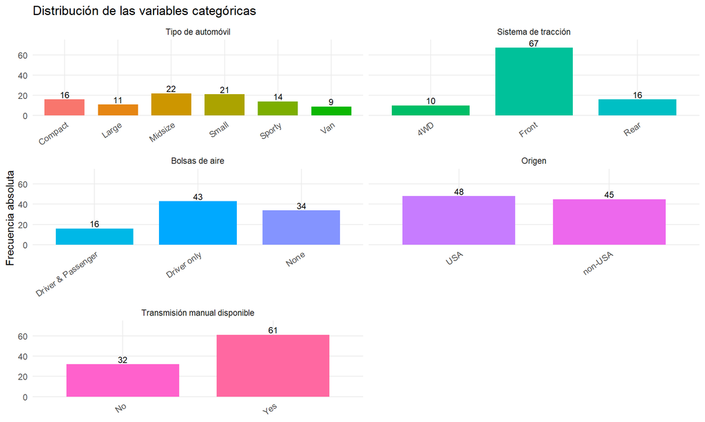

```r
# Convierte las variables categóricas a formato largo para graficarlas en un solo objeto.
datos_categoricos_largos <- datos_categoricos |>
  tidyr::pivot_longer(
    cols = dplyr::everything(),
    names_to = "variable",
    values_to = "categoria"
  )

# Reemplaza los nombres técnicos por etiquetas en español.
datos_categoricos_largos <- datos_categoricos_largos |>
  dplyr::mutate(
    variable = factor(
      variable,
      levels = names(etiquetas_categoricas),
      labels = unname(etiquetas_categoricas)
    )
  )

# Construye las barras de frecuencia para todas las variables categóricas.
grafico_barras <- ggplot2::ggplot(
  datos_categoricos_largos,
  ggplot2::aes(x = categoria, fill = categoria)
) +
  # Dibuja una barra cuya altura corresponde al número de observaciones.
  ggplot2::geom_bar(show.legend = FALSE, width = 0.75) +
  # Escribe la frecuencia absoluta encima de cada barra.
  ggplot2::geom_text(
    stat = "count",
    ggplot2::aes(label = ggplot2::after_stat(count)),
    vjust = -0.25,
    size = 3.2
  ) +
  # Construye un panel separado para cada variable.
  ggplot2::facet_wrap(~ variable, scales = "free_x", ncol = 2) +
  # Añade espacio superior para evitar cortar las etiquetas.
  ggplot2::scale_y_continuous(expand = ggplot2::expansion(mult = c(0, 0.12))) +
  # Define los títulos de los ejes y del gráfico.
  ggplot2::labs(
    title = "Distribución de las variables categóricas",
    x = NULL,
    y = "Frecuencia absoluta"
  ) +
  # Utiliza un tema de presentación limpio.
  ggplot2::theme_minimal(base_size = 11) +
  # Gira las etiquetas cuando son largas.
  ggplot2::theme(
    axis.text.x = ggplot2::element_text(angle = 35, hjust = 1),
    panel.grid.minor = ggplot2::element_blank()
  )

# Muestra el gráfico dentro del documento.
print(grafico_barras)
```

### Análisis guiado del gráfico de barras

El gráfico debe confirmar visualmente lo observado en la tabla: la altura de cada barra representa **número de automóviles**, no importancia estadística ni magnitud de una variable cuantitativa. En cada panel conviene identificar primero la categoría modal y después comprobar si existen categorías claramente minoritarias.

Una buena interpretación no dice solamente “esta barra es más alta”. Debe traducir el patrón al contexto: por ejemplo, señalar qué tipos, sistemas de tracción u orígenes predominan en la muestra y advertir que la base describe el mercado representado por `Cars93`, no necesariamente todos los automóviles de cualquier época.

> **Preguntas para resolver.** Elija dos variables categóricas y redacte una comparación completa usando frecuencia y porcentaje. ¿En cuál de ellas sería más arriesgado comparar subgrupos por el reducido número de observaciones de alguna categoría?

## 3.3 2.3. Resumen descriptivo de las variables numéricas

Para una variable cuantitativa se utilizarán medidas de posición y dispersión. La media muestral es

$$\bar{x}=\frac{1}{n}\sum_{i=1}^{n}x_i,$$

mientras que la desviación estándar muestral es

$$s=\sqrt{\frac{1}{n-1}\sum_{i=1}^{n}(x_i-\bar{x})^2}.$$

La mediana y el rango intercuartílico son complementos importantes cuando existen distribuciones asimétricas o valores extremos.

```r
# Selecciona las variables numéricas de la muestra analítica.
datos_numericos <- datos |>
  dplyr::select(dplyr::all_of(variables_numericas))

# Define una función que calcula las medidas descriptivas utilizadas en la práctica.
resumen_variable <- function(x) {
  # Devuelve un vector con tamaño muestral, media, desviación, mediana, IQR, mínimo y máximo.
  c(
    n = sum(!is.na(x)),
    media = mean(x, na.rm = TRUE),
    desviacion = stats::sd(x, na.rm = TRUE),
    mediana = stats::median(x, na.rm = TRUE),
    IQR = stats::IQR(x, na.rm = TRUE),
    minimo = min(x, na.rm = TRUE),
    maximo = max(x, na.rm = TRUE)
  )
}

# Aplica la función anterior a cada variable numérica.
resumen_numerico <- vapply(
  datos_numericos,
  resumen_variable,
  numeric(7)
)

# Transpone el resultado para dejar una variable por fila.
resumen_numerico <- as.data.frame(t(resumen_numerico))

# Copia los nombres de fila a una columna explícita llamada variable.
resumen_numerico$variable <- rownames(resumen_numerico)

# Elimina los nombres de fila porque la identificación ya quedó guardada como columna.
rownames(resumen_numerico) <- NULL

# Reordena la columna variable para que aparezca al comienzo de la tabla.
resumen_numerico <- resumen_numerico[, c("variable", setdiff(names(resumen_numerico), "variable"))]

# Sustituye los nombres técnicos por etiquetas legibles.
resumen_numerico$variable <- unname(
  etiquetas_numericas[resumen_numerico$variable]
)

# Presenta el resumen con tres cifras decimales.
knitr::kable(
  resumen_numerico,
  digits = 3,
  caption = "Resumen descriptivo de las variables numéricas"
)
```

Resumen descriptivo de las variables numéricas

| variable | n | media | desviacion | mediana | IQR | minimo | maximo |
| --- | --- | --- | --- | --- | --- | --- | --- |
| Precio | 93 | 19.510 | 9.659 | 17.7 | 11.1 | 7.4 | 61.9 |
| Rendimiento en ciudad | 93 | 22.366 | 5.620 | 21.0 | 7.0 | 15.0 | 46.0 |
| Rendimiento en carretera | 93 | 29.086 | 5.332 | 28.0 | 5.0 | 20.0 | 50.0 |
| Tamaño del motor | 93 | 2.668 | 1.037 | 2.4 | 1.5 | 1.0 | 5.7 |
| Potencia | 93 | 143.828 | 52.374 | 140.0 | 67.0 | 55.0 | 300.0 |
| Peso | 93 | 3072.903 | 589.897 | 3040.0 | 905.0 | 1695.0 | 4105.0 |

### 3.3.1 Análisis guiado del resumen numérico

Media y mediana deben leerse juntas. Cuando son próximas, la distribución puede ser relativamente equilibrada; cuando se separan, puede existir asimetría o influencia de valores extremos. La variable con mayor diferencia media–mediana, medida en unidades de su propia desviación estándar, es **Tamaño del motor**.

La desviación estándar resume dispersión alrededor de la media; el IQR resume el 50% central y es más robusto. Mínimo y máximo muestran extensión, pero no deben utilizarse solos para juzgar dispersión porque dependen fuertemente de observaciones extremas. En esta tabla conviene buscar tres señales: (1) media y mediana separadas, (2) IQR grande respecto de la escala habitual de la variable y (3) máximos muy alejados del centro.

> **Preguntas para resolver.** ¿Qué variables parecen más asimétricas al comparar media y mediana? ¿Coincide esa sospecha con los histogramas del siguiente bloque? ¿Qué variable presenta mayor dispersión relativa dentro de su propia unidad?

### 3.3.2 2.3.1. Tablas de frecuencias agrupadas para variables numéricas

Para conservar la idea de las tablas de frecuencia del material original sin añadir una dependencia adicional, se utiliza la regla de Sturges implementada por `hist(..., breaks = "Sturges", plot = FALSE)`. Para una muestra de tamaño $n$, la regla propone aproximadamente

$$k \approx 1+\log_2(n)$$

intervalos.

```r
# Define una función que transforma una variable numérica en una tabla de frecuencias agrupadas.
tabla_frecuencia_numerica <- function(x, nombre_variable) {
  # Calcula los intervalos de Sturges sin dibujar el histograma.
  h <- hist(
    x,
    breaks = "Sturges",
    plot = FALSE,
    right = TRUE,
    include.lowest = TRUE
  )

  # Construye etiquetas legibles para cada intervalo de clase.
  intervalos <- paste0(
    "(",
    head(h$breaks, -1),
    ", ",
    tail(h$breaks, -1),
    "]"
  )

  # Corrige visualmente el primer intervalo para recordar que incluye el extremo inferior.
  intervalos[1] <- sub("^\\(", "[", intervalos[1])

  # Calcula las frecuencias relativas dividiendo cada frecuencia por el total.
  frecuencias_relativas <- h$counts / sum(h$counts)

  # Devuelve una tabla con variable, intervalo y tres medidas de frecuencia.
  data.frame(
    variable = nombre_variable,
    intervalo = intervalos,
    frecuencia_absoluta = h$counts,
    frecuencia_relativa = frecuencias_relativas,
    porcentaje = 100 * frecuencias_relativas
  )
}

# Recorre todas las variables numéricas y construye una única tabla larga.
tabla_frecuencias_numericas <- purrr::imap_dfr(
  datos_numericos,
  ~ tabla_frecuencia_numerica(
    .x,
    unname(etiquetas_numericas[.y])
  )
)

# Presenta las frecuencias agrupadas dentro del documento.
knitr::kable(
  tabla_frecuencias_numericas,
  digits = 3,
  caption = "Frecuencias agrupadas mediante la regla de Sturges"
)
```

Frecuencias agrupadas mediante la regla de Sturges

| variable | intervalo | frecuencia_absoluta | frecuencia_relativa | porcentaje |
| --- | --- | --- | --- | --- |
| Precio | [5, 10] | 12 | 0.129 | 12.903 |
| Precio | (10, 15] | 21 | 0.226 | 22.581 |
| Precio | (15, 20] | 29 | 0.312 | 31.183 |
| Precio | (20, 25] | 10 | 0.108 | 10.753 |
| Precio | (25, 30] | 9 | 0.097 | 9.677 |
| Precio | (30, 35] | 5 | 0.054 | 5.376 |
| Precio | (35, 40] | 4 | 0.043 | 4.301 |
| Precio | (40, 45] | 1 | 0.011 | 1.075 |
| Precio | (45, 50] | 1 | 0.011 | 1.075 |
| Precio | (50, 55] | 0 | 0.000 | 0.000 |
| Precio | (55, 60] | 0 | 0.000 | 0.000 |
| Precio | (60, 65] | 1 | 0.011 | 1.075 |
| Rendimiento en ciudad | [15, 20] | 43 | 0.462 | 46.237 |
| Rendimiento en ciudad | (20, 25] | 32 | 0.344 | 34.409 |
| Rendimiento en ciudad | (25, 30] | 11 | 0.118 | 11.828 |
| Rendimiento en ciudad | (30, 35] | 4 | 0.043 | 4.301 |
| Rendimiento en ciudad | (35, 40] | 1 | 0.011 | 1.075 |
| Rendimiento en ciudad | (40, 45] | 1 | 0.011 | 1.075 |
| Rendimiento en ciudad | (45, 50] | 1 | 0.011 | 1.075 |
| Rendimiento en carretera | [20, 25] | 22 | 0.237 | 23.656 |
| Rendimiento en carretera | (25, 30] | 42 | 0.452 | 45.161 |
| Rendimiento en carretera | (30, 35] | 18 | 0.194 | 19.355 |
| Rendimiento en carretera | (35, 40] | 7 | 0.075 | 7.527 |
| Rendimiento en carretera | (40, 45] | 2 | 0.022 | 2.151 |
| Rendimiento en carretera | (45, 50] | 2 | 0.022 | 2.151 |
| Tamaño del motor | [1, 1.5] | 12 | 0.129 | 12.903 |
| Tamaño del motor | (1.5, 2] | 17 | 0.183 | 18.280 |
| Tamaño del motor | (2, 2.5] | 24 | 0.258 | 25.806 |
| Tamaño del motor | (2.5, 3] | 14 | 0.151 | 15.054 |
| Tamaño del motor | (3, 3.5] | 9 | 0.097 | 9.677 |
| Tamaño del motor | (3.5, 4] | 8 | 0.086 | 8.602 |
| Tamaño del motor | (4, 4.5] | 2 | 0.022 | 2.151 |
| Tamaño del motor | (4.5, 5] | 5 | 0.054 | 5.376 |
| Tamaño del motor | (5, 5.5] | 0 | 0.000 | 0.000 |
| Tamaño del motor | (5.5, 6] | 2 | 0.022 | 2.151 |
| Potencia | [50, 100] | 22 | 0.237 | 23.656 |
| Potencia | (100, 150] | 32 | 0.344 | 34.409 |
| Potencia | (150, 200] | 28 | 0.301 | 30.108 |
| Potencia | (200, 250] | 6 | 0.065 | 6.452 |
| Potencia | (250, 300] | 5 | 0.054 | 5.376 |
| Peso | [1500, 2000] | 3 | 0.032 | 3.226 |
| Peso | (2000, 2500] | 17 | 0.183 | 18.280 |
| Peso | (2500, 3000] | 25 | 0.269 | 26.882 |
| Peso | (3000, 3500] | 21 | 0.226 | 22.581 |
| Peso | (3500, 4000] | 23 | 0.247 | 24.731 |
| Peso | (4000, 4500] | 4 | 0.043 | 4.301 |

### 3.3.3 Análisis guiado de las tablas agrupadas

Las tablas convierten valores continuos en clases. El número de clases generado para cada variable es: Peso = 6 intervalos; Potencia = 5 intervalos; Precio = 12 intervalos; Rendimiento en carretera = 6 intervalos; Rendimiento en ciudad = 7 intervalos; Tamaño del motor = 10 intervalos. Esta representación facilita localizar zonas de concentración, pero sacrifica información porque todos los valores de un intervalo quedan tratados como pertenecientes a una misma clase.

La regla de Sturges es una **regla de construcción**, no una propiedad natural de los datos. Si se modifican los puntos de corte, la apariencia de la distribución también puede cambiar. Por eso una conclusión sólida debe coincidir razonablemente con el histograma, la densidad y las medidas descriptivas.

> **Preguntas para resolver.** Seleccione una variable y determine en qué intervalo se concentra la mayor frecuencia. ¿Cambiaría la historia estadística si se utilizaran más clases? Justifique sin volver a calcular todavía.

Estas tablas son útiles para describir la distribución, pero el resultado depende de los puntos de corte. Por ello deben leerse junto con histogramas, densidades y medidas descriptivas, no como una partición única o intrínseca de la variable.

## 3.4 2.4. Histogramas, densidades y diagramas de cajas

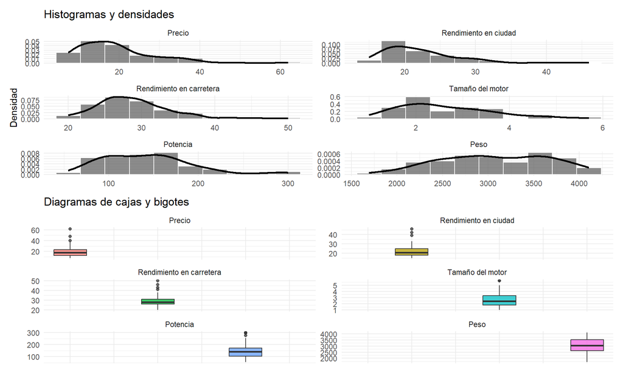

```r
# Convierte las variables numéricas a formato largo para facilitar los gráficos facetados.
datos_numericos_largos <- datos_numericos |>
  tidyr::pivot_longer(
    cols = dplyr::everything(),
    names_to = "variable",
    values_to = "valor"
  )

# Reemplaza los nombres técnicos por etiquetas en español.
datos_numericos_largos <- datos_numericos_largos |>
  dplyr::mutate(
    variable = factor(
      variable,
      levels = names(etiquetas_numericas),
      labels = unname(etiquetas_numericas)
    )
  )

# Construye histogramas en escala de densidad y superpone una densidad kernel.
grafico_histogramas <- ggplot2::ggplot(
  datos_numericos_largos,
  ggplot2::aes(x = valor)
) +
  # Representa la distribución empírica mediante intervalos.
  ggplot2::geom_histogram(
    ggplot2::aes(y = ggplot2::after_stat(density)),
    bins = 10,
    alpha = 0.70,
    colour = "white"
  ) +
  # Superpone una estimación suave de la densidad.
  ggplot2::geom_density(linewidth = 0.9) +
  # Usa escalas independientes porque las variables tienen unidades diferentes.
  ggplot2::facet_wrap(~ variable, scales = "free", ncol = 2) +
  # Define títulos y etiquetas.
  ggplot2::labs(
    title = "Histogramas y densidades",
    x = NULL,
    y = "Densidad"
  ) +
  # Aplica un tema limpio.
  ggplot2::theme_minimal(base_size = 11)

# Construye diagramas de cajas para detectar asimetría y valores potencialmente extremos.
grafico_cajas <- ggplot2::ggplot(
  datos_numericos_largos,
  ggplot2::aes(x = variable, y = valor, fill = variable)
) +
  # Dibuja caja, mediana, bigotes y puntos fuera de 1.5 veces el IQR.
  ggplot2::geom_boxplot(show.legend = FALSE, alpha = 0.75) +
  # Separa las variables para evitar comparar escalas incompatibles.
  ggplot2::facet_wrap(~ variable, scales = "free_y", ncol = 2) +
  # Define títulos del gráfico.
  ggplot2::labs(
    title = "Diagramas de cajas y bigotes",
    x = NULL,
    y = NULL
  ) +
  # Aplica un tema limpio y elimina etiquetas horizontales redundantes.
  ggplot2::theme_minimal(base_size = 11) +
  ggplot2::theme(
    axis.text.x = ggplot2::element_blank(),
    axis.ticks.x = ggplot2::element_blank()
  )

# Combina histogramas y cajas en una sola figura vertical.
grafico_histogramas / grafico_cajas
```

### Análisis guiado de histogramas, densidades y cajas

Los histogramas responden principalmente a **forma**, mientras los boxplots responden a **centro, dispersión robusta y observaciones alejadas**. En la tabla previa, la media supera a la mediana en Precio, Rendimiento en ciudad, Rendimiento en carretera, Tamaño del motor, Potencia, Peso. Ese patrón es compatible con una cola derecha, pero debe confirmarse visualmente; media mayor que mediana por sí sola no demuestra asimetría.

En los boxplots, los puntos fuera de los bigotes se definen mediante la regla de 1.5 IQR. Son **candidatos a observaciones atípicas**, no errores. En `Cars93` un automóvil caro, pesado o muy potente puede ser perfectamente real y, además, contener información importante sobre la heterogeneidad del mercado.

**Secuencia recomendada de lectura:** observe primero la modalidad y las colas del histograma; compare después media y mediana; finalmente use el boxplot para localizar extremos y valorar si éstos explican la separación entre media y mediana.

> **Preguntas para resolver.** ¿Qué variable parece más cercana a una distribución simétrica? ¿Cuál presenta la cola derecha más visible? Identifique al menos una variable donde eliminar automáticamente los puntos fuera de los bigotes sería una mala decisión sustantiva.

## 3.5 2.5. Comparación de variables numéricas según el tipo de automóvil

Para evitar producir decenas de gráficos repetitivos, se utiliza `Type` como variable categórica principal. Es la más directamente relacionada con diferencias estructurales de tamaño, potencia, consumo y precio.

```r
# Selecciona tipo de automóvil y variables numéricas.
datos_por_tipo <- datos |>
  dplyr::select(type, dplyr::all_of(variables_numericas))

# Convierte las seis variables numéricas a formato largo.
datos_por_tipo <- datos_por_tipo |>
  tidyr::pivot_longer(
    cols = dplyr::all_of(variables_numericas),
    names_to = "variable",
    values_to = "valor"
  )

# Reemplaza los nombres técnicos por etiquetas legibles.
datos_por_tipo <- datos_por_tipo |>
  dplyr::mutate(
    variable = factor(
      variable,
      levels = names(etiquetas_numericas),
      labels = unname(etiquetas_numericas)
    )
  )

# Calcula medianas por tipo para apoyar la lectura de los diagramas de cajas.
resumen_por_tipo <- datos |>
  dplyr::group_by(type) |>
  dplyr::summarise(
    n = dplyr::n(),
    precio_mediano = stats::median(price),
    potencia_mediana = stats::median(horsepower),
    peso_mediano = stats::median(weight),
    mpg_ciudad_mediano = stats::median(mpg_city),
    .groups = "drop"
  )

# Presenta las medianas para que la comparación visual tenga apoyo numérico.
knitr::kable(
  resumen_por_tipo,
  digits = 2,
  caption = "Medianas de variables seleccionadas según tipo de automóvil"
)
```

Medianas de variables seleccionadas según tipo de automóvil

| type | n | precio_mediano | potencia_mediana | peso_mediano | mpg_ciudad_mediano |
| --- | --- | --- | --- | --- | --- |
| Compact | 16 | 16.15 | 132.0 | 2970.0 | 23.0 |
| Large | 11 | 20.90 | 170.0 | 3570.0 | 19.0 |
| Midsize | 22 | 26.20 | 169.0 | 3472.5 | 19.0 |
| Small | 21 | 10.00 | 90.0 | 2345.0 | 29.0 |
| Sporty | 14 | 16.80 | 147.5 | 2857.5 | 22.5 |
| Van | 9 | 19.10 | 151.0 | 3735.0 | 17.0 |

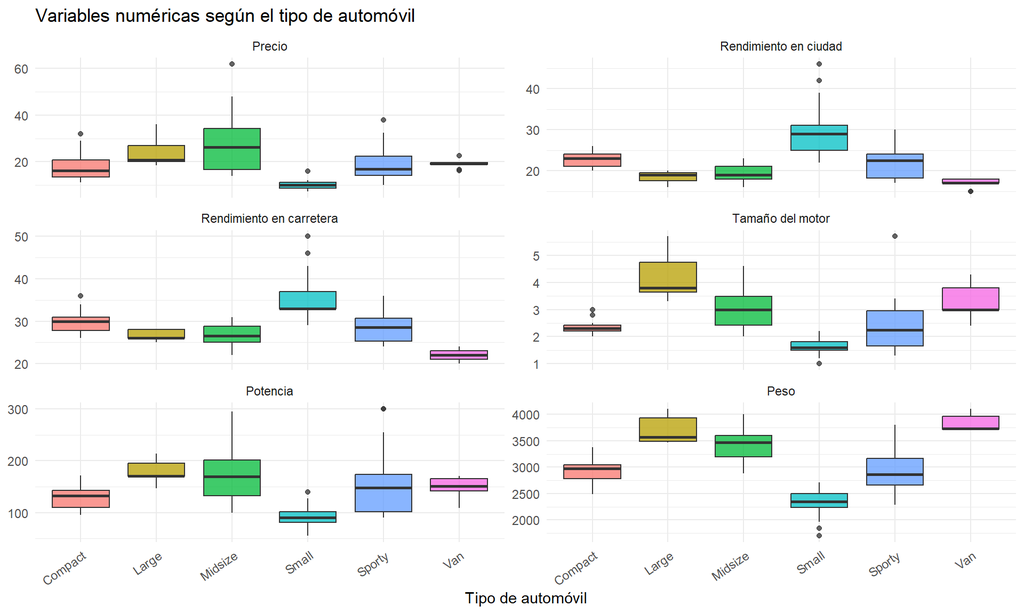

```r
# Construye diagramas de cajas por tipo de automóvil.
ggplot2::ggplot(
  datos_por_tipo,
  ggplot2::aes(x = type, y = valor, fill = type)
) +
  # Dibuja una distribución por tipo dentro de cada variable.
  ggplot2::geom_boxplot(show.legend = FALSE, alpha = 0.75) +
  # Separa las variables numéricas y permite una escala vertical propia.
  ggplot2::facet_wrap(~ variable, scales = "free_y", ncol = 2) +
  # Define títulos y ejes.
  ggplot2::labs(
    title = "Variables numéricas según el tipo de automóvil",
    x = "Tipo de automóvil",
    y = NULL
  ) +
  # Aplica un tema limpio.
  ggplot2::theme_minimal(base_size = 11) +
  # Gira las categorías para facilitar la lectura.
  ggplot2::theme(
    axis.text.x = ggplot2::element_text(angle = 35, hjust = 1)
  )
```

### Análisis guiado de las diferencias entre tipos de automóvil

La tabla de medianas permite respaldar el gráfico con números. El tipo con mayor **peso mediano** es Van; el de mayor **potencia mediana** es Large; y el de mayor **rendimiento urbano mediano** es Small.

Aquí empieza la transición del análisis univariado al multivariado. Si un mismo tipo aparece simultáneamente con mayor peso, mayor potencia, mayor precio y menor eficiencia, esas diferencias no son independientes entre sí. El ACP posterior buscará resumir precisamente esos patrones conjuntos.

Las cajas solapadas indican que una sola variable quizá no distingue bien los tipos. En cambio, el Biplot puede revelar separación al combinar varias variables simultáneamente.

> **Preguntas para resolver.** ¿Qué dos tipos muestran el contraste más fuerte entre eficiencia y potencia? ¿Una sola variable sería suficiente para distinguirlos? Proponga una explicación de por qué peso, tamaño del motor y MPG podrían moverse conjuntamente.

# 4 3. Correlación: puente entre descripción y ACP

## 4.1 3.1. Pearson y Spearman

El coeficiente de Pearson entre dos variables cuantitativas es

$$r_{XY}=\frac{\sum_{i=1}^{n}(x_i-\bar{x})(y_i-\bar{y})}
{\sqrt{\sum_{i=1}^{n}(x_i-\bar{x})^2}
\sqrt{\sum_{i=1}^{n}(y_i-\bar{y})^2}}.$$

Pearson resume asociación **lineal**. Spearman aplica el coeficiente de Pearson a los rangos y resume asociación **monótona**, por lo que suele ser menos sensible a valores extremos y no linealidad monótona.

```r
# Convierte el data frame numérico en matriz, formato requerido por Hmisc::rcorr().
matriz_numerica <- as.matrix(datos_numericos)

# Calcula correlaciones de Pearson junto con tamaños muestrales y valores p.
resultado_pearson <- Hmisc::rcorr(
  matriz_numerica,
  type = "pearson"
)

# Extrae la matriz de coeficientes de Pearson.
matriz_pearson <- resultado_pearson$r

# Extrae la matriz de valores p asociada a Pearson.
p_pearson <- resultado_pearson$P

# Calcula correlaciones de Spearman sobre las mismas variables.
resultado_spearman <- Hmisc::rcorr(
  matriz_numerica,
  type = "spearman"
)

# Extrae la matriz de coeficientes de Spearman.
matriz_spearman <- resultado_spearman$r

# Extrae la matriz de valores p asociada a Spearman.
p_spearman <- resultado_spearman$P

# Presenta la matriz de Pearson redondeada a tres cifras.
knitr::kable(
  round(matriz_pearson, 3),
  caption = "Correlaciones de Pearson"
)
```

Correlaciones de Pearson

|  | price | mpg_city | mpg_highway | engine_size | horsepower | weight |
| --- | --- | --- | --- | --- | --- | --- |
| price | 1.000 | -0.595 | -0.561 | 0.597 | 0.788 | 0.647 |
| mpg_city | -0.595 | 1.000 | 0.944 | -0.710 | -0.673 | -0.843 |
| mpg_highway | -0.561 | 0.944 | 1.000 | -0.627 | -0.619 | -0.811 |
| engine_size | 0.597 | -0.710 | -0.627 | 1.000 | 0.732 | 0.845 |
| horsepower | 0.788 | -0.673 | -0.619 | 0.732 | 1.000 | 0.739 |
| weight | 0.647 | -0.843 | -0.811 | 0.845 | 0.739 | 1.000 |

```r
# Presenta la matriz de Spearman redondeada a tres cifras.
knitr::kable(
  round(matriz_spearman, 3),
  caption = "Correlaciones de Spearman"
)
```

Correlaciones de Spearman

|  | price | mpg_city | mpg_highway | engine_size | horsepower | weight |
| --- | --- | --- | --- | --- | --- | --- |
| price | 1.000 | -0.786 | -0.723 | 0.727 | 0.858 | 0.781 |
| mpg_city | -0.786 | 1.000 | 0.936 | -0.821 | -0.789 | -0.893 |
| mpg_highway | -0.723 | 0.936 | 1.000 | -0.726 | -0.710 | -0.838 |
| engine_size | 0.727 | -0.821 | -0.726 | 1.000 | 0.814 | 0.898 |
| horsepower | 0.858 | -0.789 | -0.710 | 0.814 | 1.000 | 0.804 |
| weight | 0.781 | -0.893 | -0.838 | 0.898 | 0.804 | 1.000 |

### 4.1.1 Análisis guiado de Pearson y Spearman

Las dos matrices deben compararse, no leerse de forma aislada. Pearson mide asociación lineal sobre los valores originales; Spearman mide asociación monótona sobre rangos. Si ambos coeficientes son parecidos, la relación suele ser compatible con un patrón monótono aproximadamente lineal. Si difieren apreciablemente, conviene revisar el diagrama de dispersión: pueden existir curvatura, valores extremos o relaciones monótonas no lineales.

Los valores de la diagonal son 1 por definición y no aportan información comparativa. Además, una correlación grande **no implica causalidad** y una correlación cercana a cero sólo descarta asociación lineal fuerte, no toda forma de dependencia.

> **Preguntas para resolver.** Encuentre un par con correlación positiva fuerte y otro con correlación negativa fuerte. ¿Qué interpretación física tendría cada relación en el contexto de automóviles? ¿Esperaría que Pearson y Spearman fueran idénticos?

## 4.2 3.2. Identificación de las asociaciones más intensas

```r
# Define una función para convertir una matriz simétrica de correlaciones en pares únicos.
extraer_pares_cor <- function(matriz_cor) {
  # Conserva únicamente el triángulo superior y excluye la diagonal.
  indices <- which(upper.tri(matriz_cor), arr.ind = TRUE)

  # Construye una tabla con nombre de variables y coeficiente de correlación.
  pares <- data.frame(
    variable_1 = rownames(matriz_cor)[indices[, 1]],
    variable_2 = colnames(matriz_cor)[indices[, 2]],
    correlacion = matriz_cor[indices]
  )

  # Añade el valor absoluto para ordenar por intensidad y no por signo.
  pares$correlacion_absoluta <- abs(pares$correlacion)

  # Ordena de mayor a menor intensidad absoluta.
  pares <- pares[order(-pares$correlacion_absoluta), ]

  # Devuelve la tabla ordenada.
  pares
}

# Obtiene los pares de Pearson ordenados por intensidad.
pares_pearson <- extraer_pares_cor(matriz_pearson)

# Obtiene los pares de Spearman ordenados por intensidad.
pares_spearman <- extraer_pares_cor(matriz_spearman)

# Muestra las ocho asociaciones lineales más intensas.
knitr::kable(
  head(pares_pearson, 8),
  digits = 3,
  caption = "Asociaciones de Pearson más intensas"
)
```

Asociaciones de Pearson más intensas

|  | variable_1 | variable_2 | correlacion | correlacion_absoluta |
| --- | --- | --- | --- | --- |
| 3 | mpg_city | mpg_highway | 0.944 | 0.944 |
| 14 | engine_size | weight | 0.845 | 0.845 |
| 12 | mpg_city | weight | -0.843 | 0.843 |
| 13 | mpg_highway | weight | -0.811 | 0.811 |
| 7 | price | horsepower | 0.788 | 0.788 |
| 15 | horsepower | weight | 0.739 | 0.739 |
| 10 | engine_size | horsepower | 0.732 | 0.732 |
| 5 | mpg_city | engine_size | -0.710 | 0.710 |

```r
# Guarda correlaciones concretas que ayudarán a interpretar el Biplot.
cor_mpg <- matriz_pearson["mpg_city", "mpg_highway"]

# Guarda la asociación entre peso y tamaño del motor.
cor_peso_motor <- matriz_pearson["weight", "engine_size"]

# Guarda la asociación entre peso y rendimiento urbano.
cor_peso_mpg <- matriz_pearson["weight", "mpg_city"]

# Guarda la asociación entre precio y potencia.
cor_precio_potencia <- matriz_pearson["price", "horsepower"]

# Calcula, para cada par único, cuánto difieren Pearson y Spearman.
comparacion_correlaciones <- merge(
  pares_pearson[, c("variable_1", "variable_2", "correlacion")],
  pares_spearman[, c("variable_1", "variable_2", "correlacion")],
  by = c("variable_1", "variable_2"),
  suffixes = c("_pearson", "_spearman")
)

# Añade la diferencia absoluta entre los dos coeficientes.
comparacion_correlaciones$diferencia_absoluta <- abs(
  comparacion_correlaciones$correlacion_pearson -
    comparacion_correlaciones$correlacion_spearman
)

# Ordena los pares para encontrar dónde los dos métodos discrepan más.
comparacion_correlaciones <- comparacion_correlaciones[
  order(-comparacion_correlaciones$diferencia_absoluta),
]
```

### 4.2.1 Análisis guiado de las asociaciones dominantes

El par con mayor correlación lineal en valor absoluto es **mpg_city – mpg_highway**, con Pearson igual a 0.944. El par donde Pearson y Spearman discrepan más es **price – mpg_city**, con diferencia absoluta 0.192.

Para interpretar el futuro Biplot son especialmente útiles cuatro relaciones: MPG ciudad–MPG carretera (0.944), peso–tamaño del motor (0.845), peso–MPG ciudad (-0.843) y precio–potencia (0.788). Las dos primeras deberían producir flechas con ángulos pequeños; la relación negativa entre peso y eficiencia debería reflejarse mediante flechas aproximadamente opuestas.

Este bloque es el **puente conceptual hacia ACP**: cuando varias variables están fuertemente correlacionadas, parte de su información es redundante y puede resumirse mediante unas pocas direcciones principales.

> **Preguntas para resolver.** ¿Cuál de las correlaciones fuertes es más fácil de explicar mecánicamente? ¿Qué par muestra la mayor diferencia Pearson–Spearman y qué gráfico adicional pediría antes de interpretarlo? ¿Por qué un ACP puede ser útil cuando MPG ciudad y MPG carretera son muy redundantes?

Los valores p son útiles, pero con muchas correlaciones simultáneas debe recordarse que existe multiplicidad. En esta práctica el interés principal es **descriptivo y estructural**, no realizar una batería de decisiones binarias basada únicamente en $p<0.05$.

# 5 4. Práctica II: Análisis de Componentes Principales

## 5.1 4.1. ¿Por qué usar ACP?

Las seis variables cuantitativas no aportan información completamente independiente. El ACP construye nuevas variables incorrelacionadas llamadas componentes principales:

$$PC_k=a_{1k}Z_1+a_{2k}Z_2+\cdots+a_{pk}Z_p,$$

donde $Z_j$ son las variables estandarizadas y $a_{jk}$ son los coeficientes del vector propio correspondiente a la componente $k$.

La estandarización utilizada es

$$Z_{ij}=\frac{X_{ij}-\bar X_j}{s_j}.$$

Es importante porque precio, millas por galón, litros de motor, caballos de fuerza y libras de peso utilizan escalas incompatibles. Con `scale. = TRUE`, el ACP equivale conceptualmente a trabajar con la matriz de correlaciones.

`prcomp()` no calcula los vectores propios de la matriz de correlación de manera directa. R utiliza una **descomposición en valores singulares (SVD)** de la matriz centrada y escalada, un procedimiento numéricamente estable. Si

$$Z=UDV^{\mathsf T},$$

entonces las columnas de $V$ determinan las direcciones principales y las puntuaciones de las observaciones se obtienen proyectando $Z$ sobre esas direcciones.

## 5.2 4.2. Verificación previa y ajuste del ACP

```r
# Conserva exactamente las variables numéricas utilizadas en la sección descriptiva.
datos_acp <- datos |>
  dplyr::select(dplyr::all_of(variables_numericas))

# Calcula la desviación estándar de cada variable antes de escalar.
desviaciones <- vapply(
  datos_acp,
  stats::sd,
  numeric(1),
  na.rm = TRUE
)

# Identifica variables constantes o con desviación estándar no disponible.
variables_problematicas <- names(desviaciones)[
  is.na(desviaciones) | desviaciones == 0
]

# Detiene el análisis si una variable no puede estandarizarse.
if (length(variables_problematicas) > 0) {
  stop(
    paste(
      "No se puede realizar el ACP. Variables sin variabilidad:",
      paste(variables_problematicas, collapse = ", ")
    )
  )
}

# Ajusta el ACP centrando y estandarizando todas las variables.
pca_cars <- stats::prcomp(
  datos_acp,
  center = TRUE,
  scale. = TRUE
)

# Muestra el resumen estándar del ACP.
summary(pca_cars)
```

```
## Importance of components:
##                           PC1    PC2     PC3    PC4     PC5     PC6
## Standard deviation     2.1420 0.8137 0.63933 0.4292 0.33017 0.21864
## Proportion of Variance 0.7647 0.1103 0.06812 0.0307 0.01817 0.00797
## Cumulative Proportion  0.7647 0.8750 0.94317 0.9739 0.99203 1.00000
```

### 5.2.1 Análisis guiado del ajuste del ACP

Antes de interpretar componentes, este bloque confirma que ninguna variable tiene varianza cero y que todas pueden estandarizarse. `scale. = TRUE` es esencial porque las variables están expresadas en unidades incompatibles: dólares, millas por galón, litros, caballos de fuerza y libras. Sin estandarización, las variables con mayor varianza numérica podrían dominar artificialmente el resultado.

El `summary(pca_cars)` muestra la desviación estándar de cada componente, la proporción de varianza y la proporción acumulada. Todavía **no se deben nombrar CP1 o CP2**: primero se necesita saber qué variables están asociadas con cada eje, información que aparecerá en las cargas/correlaciones variable–componente.

> **Preguntas para resolver.** ¿Qué ocurriría si `scale. = FALSE`? ¿Por qué la variable peso podría dominar sólo por su escala? ¿Qué propiedad garantiza que las componentes principales son ortogonales entre sí?

## 5.3 4.3. Valores propios y varianza explicada

La varianza de la componente $k$ es su valor propio

$$\lambda_k=s_k^2,$$

donde `sdev[k]` es la desviación estándar devuelta por `prcomp()`. La proporción explicada es

$$P_k=\frac{\lambda_k}{\sum_{j=1}^{p}\lambda_j}.$$

```r
# Eleva al cuadrado las desviaciones de las componentes para obtener los valores propios.
valores_propios <- pca_cars$sdev^2

# Divide cada valor propio por la suma total para obtener la proporción explicada.
proporcion_varianza <- valores_propios / sum(valores_propios)

# Acumula progresivamente la proporción de varianza explicada.
proporcion_acumulada <- cumsum(proporcion_varianza)

# Organiza los resultados en una tabla interpretable.
tabla_varianza <- data.frame(
  componente = paste0("CP", seq_along(valores_propios)),
  valor_propio = valores_propios,
  porcentaje = 100 * proporcion_varianza,
  porcentaje_acumulado = 100 * proporcion_acumulada
)

# Presenta la tabla con dos cifras decimales.
knitr::kable(
  tabla_varianza,
  digits = 2,
  caption = "Varianza explicada por las componentes principales"
)
```

Varianza explicada por las componentes principales

| componente | valor_propio | porcentaje | porcentaje_acumulado |
| --- | --- | --- | --- |
| CP1 | 4.59 | 76.47 | 76.47 |
| CP2 | 0.66 | 11.03 | 87.50 |
| CP3 | 0.41 | 6.81 | 94.32 |
| CP4 | 0.18 | 3.07 | 97.39 |
| CP5 | 0.11 | 1.82 | 99.20 |
| CP6 | 0.05 | 0.80 | 100.00 |

```r
# Calcula el porcentaje de variabilidad conservado por el plano CP1-CP2.
porcentaje_plano <- 100 * sum(proporcion_varianza[1:2])

# Cuenta cuántas componentes tienen valor propio mayor que uno.
n_kaiser <- sum(valores_propios > 1)

# Identifica el mínimo número de componentes necesario para alcanzar al menos 80 %.
n_80 <- which(proporcion_acumulada >= 0.80)[1]
```

### 5.3.1 Análisis guiado de la varianza explicada

CP1 explica 76.5% y CP2 explica 11%. Juntas conservan 87.5% de la variabilidad estandarizada. Según Kaiser se retendrían 1 componentes, mientras que para alcanzar al menos 80% se necesitan 2.

Estos criterios responden a preguntas distintas. Kaiser compara cada componente con la varianza de una variable estandarizada; el umbral de 80% exige una cantidad acumulada de información. Ninguno debe utilizarse mecánicamente: también importa si las componentes retenidas son interpretables y si el objetivo es descripción, visualización o modelamiento posterior.

**Regla de lectura del Biplot:** si CP1+CP2 conserva una proporción alta, el plano es una buena síntesis; si conserva una proporción moderada, el gráfico sigue siendo útil, pero cualquier conclusión debe reconocerse como una proyección parcial.

> **Preguntas para resolver.** ¿Kaiser y el criterio del 80% recomiendan el mismo número de componentes? ¿Usaría dos componentes sólo porque el Biplot necesita dos ejes? Argumente estadísticamente.

El plano formado por CP1 y CP2 conserva 87.5% de la variabilidad total. Según el criterio de Kaiser, 1 componentes tienen valor propio superior a 1. Para alcanzar al menos 80% de varianza acumulada se requieren 2 componentes. Estas tres cantidades deben considerarse antes de interpretar un Biplot bidimensional.

## 5.4 4.4. Scree plot

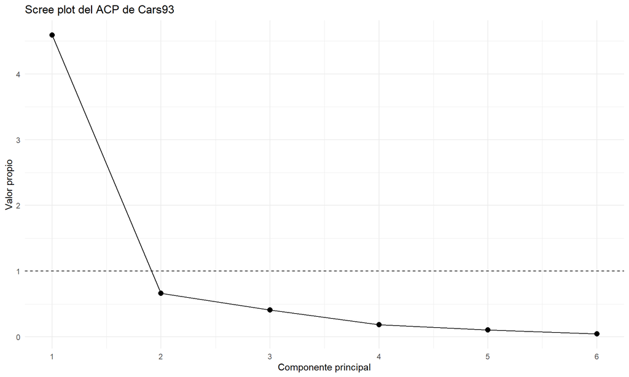

```r
# Construye una tabla de apoyo para representar los valores propios.
datos_scree <- data.frame(
  componente = seq_along(valores_propios),
  valor_propio = valores_propios
)

# Construye el gráfico de sedimentación.
ggplot2::ggplot(
  datos_scree,
  ggplot2::aes(x = componente, y = valor_propio)
) +
  # Une los valores propios para facilitar la búsqueda visual del codo.
  ggplot2::geom_line() +
  # Marca cada componente con un punto.
  ggplot2::geom_point(size = 2.5) +
  # Añade una referencia horizontal en lambda = 1 para el criterio de Kaiser.
  ggplot2::geom_hline(yintercept = 1, linetype = "dashed") +
  # Fuerza marcas enteras en el eje horizontal.
  ggplot2::scale_x_continuous(breaks = seq_along(valores_propios)) +
  # Define títulos y ejes.
  ggplot2::labs(
    title = "Scree plot del ACP de Cars93",
    x = "Componente principal",
    y = "Valor propio"
  ) +
  # Aplica un tema limpio.
  ggplot2::theme_minimal(base_size = 11)
```

### Análisis guiado del scree plot

El scree plot permite observar cómo cae la varianza de componente en componente. Debe buscarse un **codo**: un punto a partir del cual añadir componentes produce ganancias cada vez menores. La línea horizontal en $\lambda=1$ sirve únicamente como referencia para Kaiser.

Compare el codo visual con 1 componentes por Kaiser y 2 para alcanzar 80%. Si los tres criterios apuntan a una zona semejante, la decisión es más fácil de defender. Si discrepan, el estudiante debe justificar qué criterio responde mejor al objetivo del análisis.

> **Preguntas para resolver.** ¿Dónde ubicaría el codo del gráfico? ¿Coincide con Kaiser? ¿Cuánta información adicional gana al pasar de dos a tres componentes?

# 6 5. `rotation`, correlaciones variable-componente y contribuciones

Esta distinción es esencial.

- `pca_cars$rotation` contiene los **coeficientes de los vectores propios**.
- No son porcentajes de contribución.
- Cuando las variables fueron estandarizadas, una aproximación útil para interpretar el Biplot es la correlación entre cada variable y cada componente:

$$\operatorname{Cor}(Z_j,PC_k)=a_{jk}\sqrt{\lambda_k}
=a_{jk}s_k.$$

- La contribución relativa de una variable a una componente puede expresarse, para esta parametrización ortonormal, como

$$100a_{jk}^{2},$$

y suma 100% dentro de cada componente.

```r
# Extrae los coeficientes de rotación de las dos primeras componentes.
rotaciones <- pca_cars$rotation[, 1:2, drop = FALSE]

# Multiplica cada columna por la desviación de su componente para obtener correlaciones variable-componente.
cor_var_pc <- sweep(
  rotaciones,
  MARGIN = 2,
  STATS = pca_cars$sdev[1:2],
  FUN = "*"
)

# Calcula porcentajes de contribución a partir del cuadrado de los coeficientes ortonormales.
contribuciones <- 100 * rotaciones^2

# Organiza rotaciones, correlaciones y contribuciones en una tabla conjunta.
tabla_cargas <- data.frame(
  variable = unname(etiquetas_numericas[rownames(rotaciones)]),
  rotacion_CP1 = rotaciones[, 1],
  rotacion_CP2 = rotaciones[, 2],
  correlacion_CP1 = cor_var_pc[, 1],
  correlacion_CP2 = cor_var_pc[, 2],
  contribucion_CP1 = contribuciones[, 1],
  contribucion_CP2 = contribuciones[, 2]
)

# Presenta la tabla para distinguir los tres conceptos.
knitr::kable(
  tabla_cargas,
  digits = 3,
  caption = "Rotaciones, correlaciones con las componentes y contribuciones"
)
```

Rotaciones, correlaciones con las componentes y contribuciones

|  | variable | rotacion_CP1 | rotacion_CP2 | correlacion_CP1 | correlacion_CP2 | contribucion_CP1 | contribucion_CP2 |
| --- | --- | --- | --- | --- | --- | --- | --- |
| price | Precio | 0.369 | 0.596 | 0.790 | 0.485 | 13.605 | 35.480 |
| mpg_city | Rendimiento en ciudad | -0.426 | 0.413 | -0.913 | 0.336 | 18.182 | 17.022 |
| mpg_highway | Rendimiento en carretera | -0.408 | 0.490 | -0.875 | 0.399 | 16.676 | 24.017 |
| engine_size | Tamaño del motor | 0.402 | 0.082 | 0.862 | 0.067 | 16.184 | 0.673 |
| horsepower | Potencia | 0.403 | 0.457 | 0.864 | 0.372 | 16.275 | 20.862 |
| weight | Peso | 0.437 | -0.139 | 0.936 | -0.113 | 19.078 | 1.946 |

```r
# Ordena las variables por intensidad de asociación con CP1.
orden_cp1 <- order(abs(cor_var_pc[, 1]), decreasing = TRUE)

# Ordena las variables por intensidad de asociación con CP2.
orden_cp2 <- order(abs(cor_var_pc[, 2]), decreasing = TRUE)

# Conserva las tres variables más relacionadas con CP1.
top_cp1 <- rownames(cor_var_pc)[orden_cp1[1:3]]

# Conserva las tres variables más relacionadas con CP2.
top_cp2 <- rownames(cor_var_pc)[orden_cp2[1:3]]

# Convierte esos nombres técnicos a etiquetas en español.
top_cp1_etiquetas <- unname(etiquetas_numericas[top_cp1])

# Convierte las variables dominantes de CP2 a etiquetas en español.
top_cp2_etiquetas <- unname(etiquetas_numericas[top_cp2])

# Identifica variables fuertemente asociadas con un lado de CP1 en la orientación actual.
cp1_lado_positivo <- unname(
  etiquetas_numericas[rownames(cor_var_pc)[cor_var_pc[, 1] >= 0.50]]
)

# Identifica variables fuertemente asociadas con el lado opuesto de CP1.
cp1_lado_negativo <- unname(
  etiquetas_numericas[rownames(cor_var_pc)[cor_var_pc[, 1] <= -0.50]]
)

# Identifica variables fuertemente asociadas con un lado de CP2.
cp2_lado_positivo <- unname(
  etiquetas_numericas[rownames(cor_var_pc)[cor_var_pc[, 2] >= 0.50]]
)

# Identifica variables fuertemente asociadas con el lado opuesto de CP2.
cp2_lado_negativo <- unname(
  etiquetas_numericas[rownames(cor_var_pc)[cor_var_pc[, 2] <= -0.50]]
)

# Define una función auxiliar para imprimir listas vacías de forma legible.
mostrar_lista <- function(x) {
  # Devuelve una frase informativa si ninguna variable supera el umbral.
  if (length(x) == 0) return("ninguna con |correlación| ≥ 0.50")

  # Une las etiquetas restantes mediante comas.
  paste(x, collapse = ", ")
}
```

### 6.0.1 Análisis guiado de las componentes

Este es uno de los bloques más importantes de toda la práctica. Para CP1, las variables con mayor asociación absoluta son **Peso, Rendimiento en ciudad, Rendimiento en carretera**; para CP2 son **Precio, Rendimiento en carretera, Potencia**. No basta con mirar cuál tiene el número mayor: debe estudiarse el **patrón conjunto de magnitudes y signos**.

En la orientación producida por esta ejecución, CP1 contrapone Precio, Tamaño del motor, Potencia, Peso frente a Rendimiento en ciudad, Rendimiento en carretera. CP2 contrapone ninguna con |correlación| ≥ 0.50 frente a ninguna con |correlación| ≥ 0.50. Si, por ejemplo, peso, tamaño del motor y potencia aparecen en un lado y MPG en el opuesto, una interpretación razonable sería una dimensión de **tamaño/desempeño versus eficiencia**. El nombre conceptual debe surgir de los datos, no imponerse antes de ver las cargas.

La columna `contribucion_CP1` responde a “¿qué proporción de la dirección CP1 procede de esta variable?”, mientras `correlacion_CP1` responde a “¿qué tan asociada está esta variable con las puntuaciones de CP1?”. Son preguntas relacionadas, pero no idénticas.

> **Preguntas para resolver.** Proponga un nombre sustantivo para CP1 y otro para CP2. Justifique cada nombre citando al menos tres variables y sus signos. ¿Cambiaría su conclusión si todos los signos de CP1 se invirtieran?

> **Advertencia sobre los signos.** En PCA el signo de un vector propio es arbitrario. Una instalación de R podría producir CP1 con todos los signos invertidos sin cambiar ninguna conclusión geométrica. Por ello debe hablarse de **oposición entre direcciones** y de variables que se mueven juntas, no asignar un significado sustantivo absoluto a “positivo” y “negativo”.

# 7 6. Construcción de un Biplot interpretable

> **Nota sobre la definición de Biplot.** Un Biplot de Gabriel en sentido estricto distribuye los valores singulares entre las coordenadas de filas y columnas mediante escalas complementarias. En esta práctica se construye deliberadamente un **Biplot de correlación orientado a interpretación**: las observaciones conservan sus *scores* de `prcomp()` y las variables se representan mediante sus correlaciones con CP1 y CP2. Un único factor común agranda las flechas sólo para hacerlas visibles. Por tanto, se conservan las direcciones y relaciones angulares entre flechas y la geometría entre observaciones, pero no deben interpretarse literalmente productos internos o distancias entre un punto y la punta de una flecha como en un Biplot estricto.

## 7.1 6.1. Puntuaciones de las observaciones

Las puntuaciones son las coordenadas de cada automóvil en el nuevo sistema de componentes:

$$T=ZV.$$

```r
# Extrae las puntuaciones de los automóviles sobre CP1 y CP2.
puntuaciones <- as.data.frame(
  pca_cars$x[, 1:2, drop = FALSE]
)

# Asigna nombres simples a las dos coordenadas principales.
names(puntuaciones) <- c("CP1", "CP2")

# Añade el tipo de automóvil para colorear los puntos.
puntuaciones$Tipo <- datos$type

# Construye una etiqueta identificadora combinando fabricante y modelo.
puntuaciones$Automovil <- paste(
  datos$manufacturer,
  datos$model
)

# Calcula la distancia de cada automóvil al origen del plano principal.
puntuaciones$Distancia <- sqrt(
  puntuaciones$CP1^2 + puntuaciones$CP2^2
)

# Selecciona los ocho automóviles más alejados del centro para etiquetarlos sin saturar el gráfico.
indices_etiquetas <- order(
  puntuaciones$Distancia,
  decreasing = TRUE
)[1:min(8, nrow(puntuaciones))]

# Guarda únicamente esas observaciones extremas para sus etiquetas.
puntuaciones_etiquetadas <- puntuaciones[
  indices_etiquetas,
  ,
  drop = FALSE
]

# Ordena esas observaciones de mayor a menor distancia para facilitar su interpretación.
puntuaciones_etiquetadas <- puntuaciones_etiquetadas[
  order(-puntuaciones_etiquetadas$Distancia),
  ,
  drop = FALSE
]
```

### 7.1.1 Análisis guiado de las puntuaciones de los automóviles

Las puntuaciones localizan cada automóvil en las nuevas dimensiones. Los ocho casos más alejados del origen y, por tanto, con perfiles más extremos en el plano CP1–CP2 son: Geo Metro, Honda Civic, Suzuki Swift, Infiniti Q45, Cadillac Seville, Chevrolet Corvette, Mercedes-Benz 300E, Subaru Justy.

“Extremo” aquí no significa “erróneo”. Significa que el perfil estandarizado del automóvil difiere del centro en las dimensiones que resumen CP1 y CP2. Un automóvil cerca del origen posee un perfil relativamente promedio **en este plano**, aunque podría ser extremo en CP3 u otra componente no representada.

> **Preguntas para resolver.** Elija dos automóviles etiquetados y determine en qué componentes son extremos. ¿Están alejados por la misma razón? Use las variables dominantes de CP1 y CP2 para justificar.

## 7.2 6.2. Coordenadas de las variables

Para las flechas utilizaremos las **correlaciones variable-componente**. Como estas correlaciones pertenecen aproximadamente al intervalo $[-1,1]$, mientras las puntuaciones de los automóviles tienen otra escala, se multiplicarán por un único factor gráfico para superponerlas.

Ese factor **no cambia direcciones, ángulos ni proporciones entre flechas**, pero sí impide interpretar literalmente la distancia entre la punta de una flecha y un automóvil.

```r
# Convierte las correlaciones variable-componente en un data frame.
coordenadas_variables <- as.data.frame(cor_var_pc)

# Asigna nombres claros a las coordenadas de los dos ejes.
names(coordenadas_variables) <- c("CP1", "CP2")

# Añade una etiqueta en español para cada variable.
coordenadas_variables$Variable <- unname(
  etiquetas_numericas[rownames(coordenadas_variables)]
)

# Calcula la extensión máxima de las puntuaciones sobre CP1.
max_score_cp1 <- max(abs(puntuaciones$CP1))

# Calcula la extensión máxima de las puntuaciones sobre CP2.
max_score_cp2 <- max(abs(puntuaciones$CP2))

# Calcula la extensión máxima de las correlaciones sobre CP1.
max_var_cp1 <- max(abs(coordenadas_variables$CP1))

# Calcula la extensión máxima de las correlaciones sobre CP2.
max_var_cp2 <- max(abs(coordenadas_variables$CP2))

# Obtiene un único factor visual que hace caber las flechas dentro de la nube de puntos.
factor_flechas <- 0.75 * min(
  max_score_cp1 / max_var_cp1,
  max_score_cp2 / max_var_cp2
)

# Escala horizontalmente todas las flechas con el mismo factor.
coordenadas_variables$CP1_grafico <- coordenadas_variables$CP1 * factor_flechas

# Escala verticalmente todas las flechas con el mismo factor.
coordenadas_variables$CP2_grafico <- coordenadas_variables$CP2 * factor_flechas
```

### 7.2.1 Análisis guiado del escalamiento de las flechas

El factor visual calculado es 3.969. Su único propósito es llevar correlaciones, originalmente en una escala cercana a $[-1,1]$, al mismo lienzo donde aparecen las puntuaciones de los automóviles. Todas las flechas se multiplican por **el mismo factor**, por lo que se conservan sus direcciones, ángulos y longitudes relativas.

No debe interpretarse la distancia numérica entre una punta de flecha y un punto como una distancia estadística común. Lo interpretable es la **dirección** de la flecha y la **proyección aproximada** de un automóvil sobre ella.

> **Preguntas para resolver.** ¿Qué propiedad geométrica se perdería si cada flecha se escalara con un factor diferente? ¿Por qué un único factor común es preferible?

## 7.3 6.3. Elipses descriptivas por tipo de automóvil

```r
# Cuenta cuántos automóviles existen dentro de cada tipo.
frecuencias_tipo <- table(puntuaciones$Tipo)

# Identifica grupos con al menos tres observaciones.
tipos_con_elipse <- names(
  frecuencias_tipo[frecuencias_tipo >= 3]
)

# Identifica grupos con menos de tres observaciones, para los cuales no se dibujará elipse.
tipos_sin_elipse <- names(
  frecuencias_tipo[frecuencias_tipo < 3]
)

# Conserva únicamente esos grupos para el cálculo de elipses.
datos_elipses <- puntuaciones[
  puntuaciones$Tipo %in% tipos_con_elipse,
  ,
  drop = FALSE
]

# Elimina niveles vacíos después de filtrar.
datos_elipses$Tipo <- droplevels(datos_elipses$Tipo)
```

### 7.3.1 Análisis guiado de los grupos para elipses

Se dibujarán elipses para 6 tipos: Compact, Large, Midsize, Small, Sporty, Van. Los tipos excluidos por tener menos de tres observaciones son: ninguno.

El umbral de tres observaciones es apenas una condición mínima computacional; con grupos pequeños una elipse sigue siendo inestable. Por ello las elipses deben leerse como **resúmenes visuales**, nunca como regiones poblacionales exactas ni fronteras de clasificación.

> **Preguntas para resolver.** ¿Qué grupo tiene menor tamaño? ¿Confiaría igual en su elipse que en la de un grupo grande? Explique la diferencia entre “separación visual” y “evidencia formal de grupos distintos”.

Las elipses que aparecerán a continuación son **resúmenes descriptivos** de la dispersión de cada tipo bajo una aproximación elíptica. No constituyen fronteras de clasificación y no demuestran por sí solas la existencia de conglomerados.

## 7.4 6.4. Biplot principal

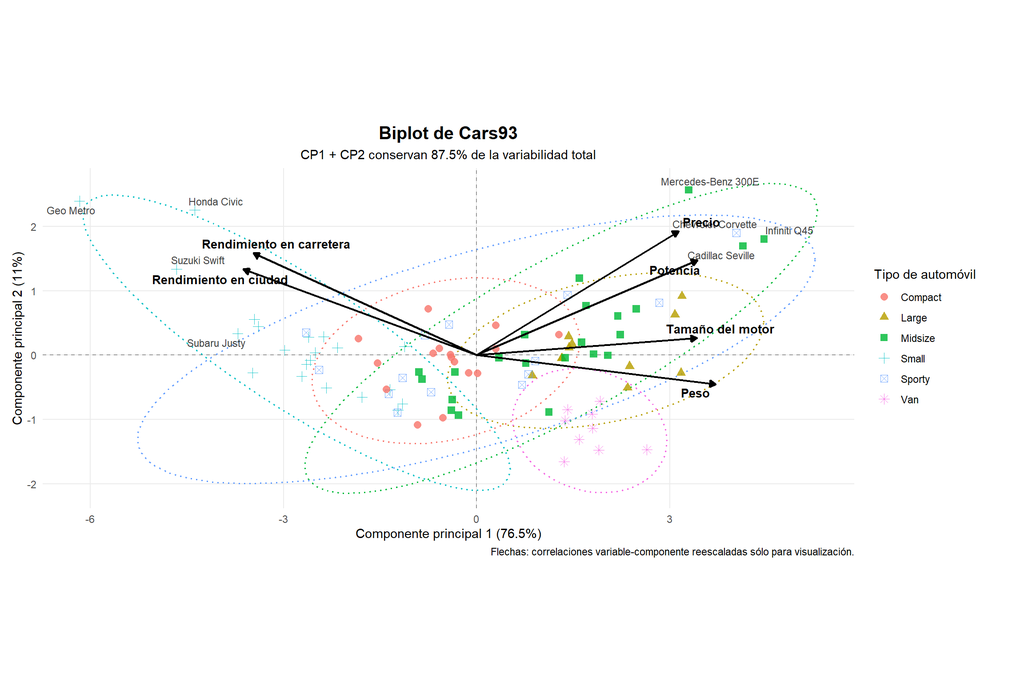

```r
# Inicializa el lienzo del Biplot.
grafico_biplot <- ggplot2::ggplot() +
  # Dibuja el eje horizontal de referencia que pasa por el origen.
  ggplot2::geom_hline(
    yintercept = 0,
    linetype = "dashed",
    linewidth = 0.4,
    colour = "grey60"
  ) +
  # Dibuja el eje vertical de referencia que pasa por el origen.
  ggplot2::geom_vline(
    xintercept = 0,
    linetype = "dashed",
    linewidth = 0.4,
    colour = "grey60"
  ) +
  # Añade elipses descriptivas para los tipos con tamaño suficiente.
  ggplot2::stat_ellipse(
    data = datos_elipses,
    ggplot2::aes(x = CP1, y = CP2, colour = Tipo, group = Tipo),
    type = "norm",
    level = 0.95,
    linewidth = 0.6,
    linetype = "dotted",
    show.legend = FALSE
  ) +
  # Representa cada automóvil mediante sus puntuaciones CP1 y CP2.
  ggplot2::geom_point(
    data = puntuaciones,
    ggplot2::aes(x = CP1, y = CP2, colour = Tipo, shape = Tipo),
    size = 2.6,
    alpha = 0.82
  ) +
  # Etiqueta únicamente los automóviles más alejados del centro.
  ggrepel::geom_text_repel(
    data = puntuaciones_etiquetadas,
    ggplot2::aes(x = CP1, y = CP2, label = Automovil),
    size = 3,
    colour = "grey25",
    show.legend = FALSE,
    max.overlaps = Inf
  ) +
  # Dibuja una flecha desde el origen para cada variable original.
  ggplot2::geom_segment(
    data = coordenadas_variables,
    ggplot2::aes(
      x = 0,
      y = 0,
      xend = CP1_grafico,
      yend = CP2_grafico
    ),
    inherit.aes = FALSE,
    linewidth = 0.8,
    colour = "black",
    arrow = grid::arrow(length = grid::unit(0.20, "cm"), type = "closed")
  ) +
  # Coloca los nombres de las variables cerca de las puntas de las flechas.
  ggrepel::geom_text_repel(
    data = coordenadas_variables,
    ggplot2::aes(
      x = CP1_grafico,
      y = CP2_grafico,
      label = Variable
    ),
    inherit.aes = FALSE,
    size = 3.6,
    fontface = "bold",
    colour = "black",
    max.overlaps = Inf
  ) +
  # Mantiene una misma unidad visual en ambos ejes.
  ggplot2::coord_equal(clip = "off") +
  # Define títulos e incorpora el porcentaje explicado por cada componente.
  ggplot2::labs(
    title = "Biplot de Cars93",
    subtitle = paste0(
      "CP1 + CP2 conservan ",
      round(porcentaje_plano, 1),
      "% de la variabilidad total"
    ),
    x = paste0("Componente principal 1 (", round(100 * proporcion_varianza[1], 1), "%)"),
    y = paste0("Componente principal 2 (", round(100 * proporcion_varianza[2], 1), "%)"),
    colour = "Tipo de automóvil",
    shape = "Tipo de automóvil",
    caption = "Flechas: correlaciones variable-componente reescaladas sólo para visualización."
  ) +
  # Aplica un tema limpio.
  ggplot2::theme_minimal(base_size = 11) +
  # Ajusta título, cuadrícula y márgenes.
  ggplot2::theme(
    plot.title = ggplot2::element_text(face = "bold", hjust = 0.5, size = 15),
    plot.subtitle = ggplot2::element_text(hjust = 0.5),
    panel.grid.minor = ggplot2::element_blank(),
    legend.position = "right",
    plot.margin = ggplot2::margin(10, 35, 10, 10)
  )

# Muestra el Biplot terminado.
print(grafico_biplot)
```

### Análisis detallado del Biplot de `Cars93`

La lectura debe comenzar por los ejes, no por los colores. CP1 está principalmente asociado con **Peso, Rendimiento en ciudad, Rendimiento en carretera** y CP2 con **Precio, Rendimiento en carretera, Potencia**. El plano conserva 87.5% de la variabilidad; por tanto, las conclusiones son una síntesis de esa fracción de información y no de las seis dimensiones completas.

**Flechas.** MPG ciudad y MPG carretera presentan correlación 0.944, así que deben verse casi paralelas. Peso y tamaño del motor, con correlación 0.845, también deberían señalar direcciones semejantes. En contraste, peso y MPG ciudad tienen correlación -0.843: si el valor es fuertemente negativo, sus flechas deberían aparecer aproximadamente enfrentadas. Esa geometría permite traducir el gráfico a una historia sustantiva: automóviles grandes/pesados/potentes tienden a diferenciarse de automóviles eficientes en consumo.

**Puntos.** Automóviles próximos comparten perfiles semejantes en las variables que mejor representan CP1 y CP2. Los casos etiquetados son deliberadamente los más alejados del origen, por lo que sirven para preguntar *qué combinación de características los hace distintos*. La proyección de un punto en la dirección de una flecha sugiere valores relativamente altos de esa variable; la dirección opuesta sugiere valores relativamente bajos.

**Grupos.** Los colores permiten explorar si los tipos de automóvil ocupan regiones diferentes, pero una superposición considerable es perfectamente posible. Si dos tipos se separan sobre CP1, la explicación debe buscarse en las variables que dominan CP1; si la separación ocurre verticalmente, debe buscarse en CP2. Las elipses no convierten el gráfico en un clasificador.

**Qué no debe decirse.** No es correcto afirmar que una flecha “causa” otra, que una elipse demuestra un cluster verdadero, ni que dos automóviles cercanos son idénticos en todas las variables originales. El Biplot es una proyección descriptiva.

> **Preguntas para resolver.** Identifique un automóvil proyectado en la dirección de mayor peso/potencia y otro en la dirección de mayor eficiencia. ¿Qué tipos son? ¿Qué par de flechas forma el ángulo más pequeño? ¿Qué relación observada en la matriz de correlación confirma esa geometría?

# 8 7. Cómo interpretar correctamente el Biplot

La interpretación debe hacerse en varias capas.

## 8.1 7.1. Primero: calidad del plano

CP1 y CP2 conservan 87.5% de la variabilidad de las seis variables. Por tanto, toda interpretación del gráfico es una **aproximación bidimensional**. Las relaciones que dependan fuertemente de CP3 o componentes posteriores pueden verse deformadas.

## 8.2 7.2. Segundo: longitud de las flechas

Las coordenadas originales de las flechas son correlaciones entre cada variable y CP1/CP2. Una flecha larga en el plano indica que la variable está bien representada por esas dos componentes:

$$\cos^2_j(1,2)
=\operatorname{Cor}(X_j,PC_1)^2+
\operatorname{Cor}(X_j,PC_2)^2.$$

```r
# Calcula la calidad de representación de cada variable en el plano CP1-CP2.
calidad_variables <- rowSums(cor_var_pc^2)

# Organiza la calidad junto con el nombre legible de cada variable.
tabla_calidad <- data.frame(
  variable = unname(etiquetas_numericas[names(calidad_variables)]),
  calidad_CP1_CP2 = calidad_variables
)

# Ordena de mejor a peor representación en el plano.
tabla_calidad <- tabla_calidad[order(-tabla_calidad$calidad_CP1_CP2), ]

# Guarda la variable mejor representada por CP1 y CP2.
variable_mejor_representada <- tabla_calidad$variable[1]

# Guarda la variable peor representada por CP1 y CP2.
variable_peor_representada <- tabla_calidad$variable[nrow(tabla_calidad)]

# Presenta la tabla de calidad de representación.
knitr::kable(
  tabla_calidad,
  digits = 3,
  caption = "Calidad de representación de las variables en el plano CP1-CP2"
)
```

Calidad de representación de las variables en el plano CP1-CP2

|  | variable | calidad_CP1_CP2 |
| --- | --- | --- |
| mpg_city | Rendimiento en ciudad | 0.947 |
| mpg_highway | Rendimiento en carretera | 0.924 |
| weight | Peso | 0.888 |
| horsepower | Potencia | 0.885 |
| price | Precio | 0.859 |
| engine_size | Tamaño del motor | 0.747 |

### 8.2.1 Análisis guiado de la calidad de representación

La variable mejor representada en CP1–CP2 es **Rendimiento en ciudad** y la peor representada es **Tamaño del motor**. Un valor de calidad próximo a 1 indica que casi toda la relación de esa variable con el espacio estandarizado queda reflejada en el plano; un valor menor significa que CP3 y componentes posteriores contienen información relevante para esa variable.

Esta tabla es esencial para evitar una interpretación excesiva de las flechas. Si una variable está pobremente representada, su ángulo respecto de otras flechas puede ser una aproximación débil de la correlación original.

> **Preguntas para resolver.** ¿Qué variables interpretaría con mayor confianza en el Biplot? ¿Cuál debería analizar además en CP3? Compare su respuesta con la longitud visual de las flechas.

Una variable con valor cercano a 1 está casi completamente representada en el plano. Una variable con valor pequeño requiere componentes adicionales para describirse adecuadamente.

## 8.3 7.3. Tercero: ángulos entre flechas

Cuando dos flechas forman un ángulo pequeño, las variables tienden a estar positivamente relacionadas. Cuando apuntan aproximadamente en direcciones opuestas, la asociación tiende a ser negativa. Un ángulo cercano a 90° sugiere una relación lineal débil en la representación retenida.

En `Cars93` se obtuvo previamente:

- $r(\text{MPG ciudad},\text{MPG carretera})=0.944$. Sus flechas deberían aparecer casi paralelas.
- $r(\text{Peso},\text{Tamaño del motor})=0.845$. Sus vectores deberían orientarse de manera parecida.
- $r(\text{Peso},\text{MPG ciudad})=-0.843$. El signo negativo explica por qué eficiencia y peso tienden a proyectarse en sentidos opuestos.
- $r(\text{Precio},\text{Potencia})=0.788$. Una orientación semejante entre ambas flechas indicará que parte de su asociación queda capturada por el plano.

Los ángulos son una **aproximación** a las correlaciones originales: cuanto mayor sea la varianza explicada por las primeras dos componentes y mejor representadas estén las variables, más confiable será esta lectura.

## 8.4 7.4. Cuarto: posición de los automóviles

Dos automóviles cercanos en el plano tienen perfiles estandarizados semejantes respecto de las variables que dominan CP1 y CP2. Una gran separación indica diferencias en esos perfiles, pero no constituye una distancia exacta en el espacio original de seis dimensiones.

La proyección conceptual de un automóvil sobre una flecha ayuda a identificar si posee valores relativamente altos o bajos de esa variable. Automóviles proyectados en la misma dirección de una flecha tienden a presentar valores altos de la variable; los ubicados en la dirección opuesta tienden a presentar valores bajos.

## 8.5 7.5. Quinto: interpretación de los grupos

```r
# Calcula el centro promedio de cada tipo de automóvil en el plano principal.
centroides_tipo <- puntuaciones |>
  dplyr::group_by(Tipo) |>
  dplyr::summarise(
    CP1 = mean(CP1),
    CP2 = mean(CP2),
    n = dplyr::n(),
    .groups = "drop"
  )

# Presenta los centroides para apoyar la interpretación gráfica.
knitr::kable(
  centroides_tipo,
  digits = 3,
  caption = "Centroides de los tipos de automóvil en el plano CP1-CP2"
)
```

Centroides de los tipos de automóvil en el plano CP1-CP2

| Tipo | CP1 | CP2 | n |
| --- | --- | --- | --- |
| Compact | -0.478 | -0.086 | 16 |
| Large | 2.000 | 0.070 | 11 |
| Midsize | 1.308 | 0.260 | 22 |
| Small | -2.800 | 0.195 | 21 |
| Sporty | -0.008 | 0.092 | 14 |
| Van | 1.753 | -1.169 | 9 |

```r
# Identifica el grupo con el centroide más alto sobre CP1.
tipo_cp1_max <- as.character(
  centroides_tipo$Tipo[which.max(centroides_tipo$CP1)]
)

# Identifica el grupo con el centroide más bajo sobre CP1.
tipo_cp1_min <- as.character(
  centroides_tipo$Tipo[which.min(centroides_tipo$CP1)]
)

# Identifica el grupo con el centroide más alto sobre CP2.
tipo_cp2_max <- as.character(
  centroides_tipo$Tipo[which.max(centroides_tipo$CP2)]
)

# Identifica el grupo con el centroide más bajo sobre CP2.
tipo_cp2_min <- as.character(
  centroides_tipo$Tipo[which.min(centroides_tipo$CP2)]
)
```

### 8.5.1 Análisis guiado de los centroides por tipo

Los centroides resumen la posición promedio de cada tipo en el plano. Sobre CP1, los extremos son **Small** y **Large**; sobre CP2 son **Van** y **Midsize**. La interpretación sustantiva de esa separación depende de las variables que dominan cada componente.

No debe compararse sólo el centro: también importa la dispersión alrededor de él. Dos tipos pueden tener centroides distintos pero elipses muy superpuestas, lo que indicaría diferencias promedio con escasa separación individual. Por el contrario, centroides alejados y poca superposición proporcionan una estructura visual más marcada.

> **Preguntas para resolver.** Use las cargas de CP1 para explicar por qué Small y Large quedan en extremos opuestos. ¿La separación entre sus centroides también se observa en los boxplots por tipo?

En CP1, los centroides más separados corresponden a Small y Large; en CP2 los extremos corresponden a Van y Midsize. El significado sustantivo de esa separación debe deducirse observando **qué flechas dominan cada eje**. No se interpreta el signo por sí solo.

Las elipses ayudan a visualizar dispersión y superposición. Si dos elipses se superponen fuertemente, las primeras dos componentes no separan claramente esos tipos. Si aparecen alejadas, existe una diferencia multivariada visible en el plano, pero ello no equivale a una prueba formal de clasificación.

# 9 8. Función reutilizable para Biplots de correlación

Para los ejemplos adicionales se encapsula la misma lógica en una función. La función no cambia la definición estadística utilizada en `Cars93`: las flechas parten de las correlaciones variable-componente y se reescalan sólo para mostrarlas junto a los *scores*.

```r
# Define una función reutilizable para construir Biplots de correlación.
crear_biplot_correlacion <- function(pca, grupo = NULL, titulo = "Biplot") {
  # Extrae las puntuaciones de las observaciones sobre CP1 y CP2.
  scores <- as.data.frame(pca$x[, 1:2, drop = FALSE])

  # Renombra las columnas para mantener una sintaxis uniforme.
  names(scores) <- c("CP1", "CP2")

  # Añade el grupo si el usuario suministró una variable categórica.
  if (!is.null(grupo)) {
    scores$Grupo <- as.factor(grupo)
  }

  # Calcula correlaciones aproximadas entre variables originales y las dos primeras componentes.
  var_pc <- sweep(
    pca$rotation[, 1:2, drop = FALSE],
    MARGIN = 2,
    STATS = pca$sdev[1:2],
    FUN = "*"
  )

  # Convierte las coordenadas de variables en un data frame.
  variables <- as.data.frame(var_pc)

  # Asigna nombres simples a las coordenadas.
  names(variables) <- c("CP1", "CP2")

  # Conserva los nombres originales de las variables para las etiquetas.
  variables$Variable <- rownames(variables)

  # Calcula un factor visual común para llevar las flechas a la escala de los puntos.
  factor_visual <- 0.75 * min(
    max(abs(scores$CP1)) / max(abs(variables$CP1)),
    max(abs(scores$CP2)) / max(abs(variables$CP2))
  )

  # Reescala horizontalmente las coordenadas de las flechas.
  variables$CP1_grafico <- variables$CP1 * factor_visual

  # Reescala verticalmente las coordenadas de las flechas.
  variables$CP2_grafico <- variables$CP2 * factor_visual

  # Calcula el porcentaje de variabilidad explicado por cada componente.
  prop <- pca$sdev^2 / sum(pca$sdev^2)

  # Inicia el gráfico vacío.
  g <- ggplot2::ggplot() +
    # Añade referencias en el origen.
    ggplot2::geom_hline(yintercept = 0, linetype = "dashed", colour = "grey70") +
    ggplot2::geom_vline(xintercept = 0, linetype = "dashed", colour = "grey70")

  # Dibuja los puntos coloreados si existe una variable de grupo.
  if (!is.null(grupo)) {
    g <- g +
      ggplot2::geom_point(
        data = scores,
        ggplot2::aes(x = CP1, y = CP2, colour = Grupo),
        size = 2.5,
        alpha = 0.80
      )
  } else {
    # Dibuja puntos sin agrupación cuando no se suministra un factor.
    g <- g +
      ggplot2::geom_point(
        data = scores,
        ggplot2::aes(x = CP1, y = CP2),
        size = 2.5,
        alpha = 0.80
      )
  }

  # Añade las flechas de las variables.
  g <- g +
    ggplot2::geom_segment(
      data = variables,
      ggplot2::aes(x = 0, y = 0, xend = CP1_grafico, yend = CP2_grafico),
      inherit.aes = FALSE,
      arrow = grid::arrow(length = grid::unit(0.18, "cm")),
      linewidth = 0.7
    ) +
    # Añade etiquetas de variables evitando superposiciones.
    ggrepel::geom_text_repel(
      data = variables,
      ggplot2::aes(x = CP1_grafico, y = CP2_grafico, label = Variable),
      inherit.aes = FALSE,
      fontface = "bold",
      size = 3.4,
      max.overlaps = Inf
    ) +
    # Mantiene la misma escala geométrica en los dos ejes.
    ggplot2::coord_equal() +
    # Define títulos y porcentajes de varianza.
    ggplot2::labs(
      title = titulo,
      x = paste0("CP1 (", round(100 * prop[1], 1), "%)"),
      y = paste0("CP2 (", round(100 * prop[2], 1), "%)"),
      colour = "Grupo"
    ) +
    # Aplica un tema limpio.
    ggplot2::theme_minimal(base_size = 11)

  # Devuelve el objeto ggplot terminado.
  g
}
```

### 9.0.1 Lectura del bloque de función reutilizable

Este bloque no analiza una base concreta; encapsula el procedimiento gráfico para reutilizarlo. La función recibe un objeto `prcomp`, una agrupación opcional y un título, y devuelve un objeto `ggplot`. Dentro de la función se repiten exactamente las decisiones ya justificadas: scores para las observaciones, correlaciones variable–componente para las flechas y un único factor visual común.

Para un estudiante, este es un ejemplo de una buena práctica de programación: **primero se comprende el procedimiento paso a paso y sólo después se automatiza**. Automatizar antes de entender puede ocultar decisiones estadísticas importantes.

> **Pregunta para resolver.** ¿Qué información adicional tendría que recibir la función si se quisiera etiquetar automáticamente sólo las cinco observaciones más extremas?

# 10 9. Extensión A: ACP y Biplot con `iris`

Este ejemplo conserva la idea del archivo original, pero evita repetir toda la teoría.

```r
# Carga iris, una base incorporada en R.
data("iris")

# Selecciona las cuatro variables cuantitativas.
iris_numerico <- iris[, 1:4]

# Ajusta un ACP con variables centradas y estandarizadas.
pca_iris <- stats::prcomp(
  iris_numerico,
  center = TRUE,
  scale. = TRUE
)

# Calcula la proporción de varianza explicada.
prop_iris <- pca_iris$sdev^2 / sum(pca_iris$sdev^2)

# Calcula correlaciones aproximadas entre las variables de iris y CP1-CP2.
cor_iris_pc <- sweep(
  pca_iris$rotation[, 1:2, drop = FALSE],
  MARGIN = 2,
  STATS = pca_iris$sdev[1:2],
  FUN = "*"
)

# Identifica la variable más asociada en valor absoluto con CP1.
top_iris_cp1 <- rownames(cor_iris_pc)[which.max(abs(cor_iris_pc[, 1]))]

# Identifica la variable más asociada en valor absoluto con CP2.
top_iris_cp2 <- rownames(cor_iris_pc)[which.max(abs(cor_iris_pc[, 2]))]

# Presenta el resumen del ACP.
summary(pca_iris)
```

```
## Importance of components:
##                           PC1    PC2     PC3     PC4
## Standard deviation     1.7084 0.9560 0.38309 0.14393
## Proportion of Variance 0.7296 0.2285 0.03669 0.00518
## Cumulative Proportion  0.7296 0.9581 0.99482 1.00000
```

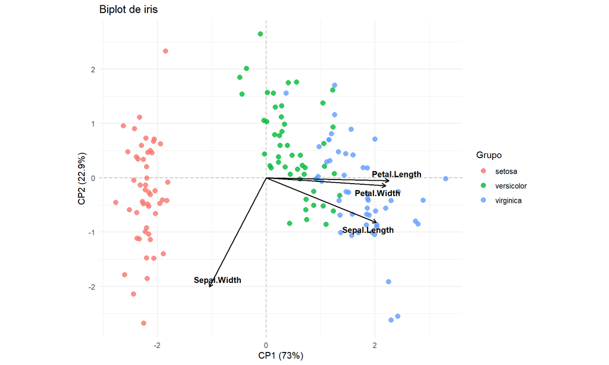

```r
# Construye el Biplot utilizando Species como agrupación descriptiva.
grafico_iris <- crear_biplot_correlacion(
  pca = pca_iris,
  grupo = iris$Species,
  titulo = "Biplot de iris"
)

# Muestra el gráfico.
print(grafico_iris)
```

### Análisis guiado de `iris`

Las dos primeras componentes explican 95.8% de la variabilidad estandarizada. La variable más asociada en valor absoluto con CP1 es **Petal.Length** y con CP2 es **Sepal.Width**. Esta información debe usarse para explicar la separación de las especies antes de mirar únicamente los colores.

En `iris`, las variables de pétalo suelen contener gran parte de la separación entre especies. Si sus flechas son cercanas, eso indica redundancia estructural; si una especie se proyecta claramente en esa dirección, sus flores tienden a presentar valores relativamente altos en esas medidas.

> **Preguntas para resolver.** ¿Qué especie aparece más separada en el plano? ¿La separación está asociada principalmente con variables de pétalo o sépalo? ¿Qué especies muestran mayor superposición y qué implica descriptivamente?

# 11 10. Extensión B: ACP y Biplot con `USArrests`

Este conjunto es especialmente útil para ilustrar por qué la estandarización es necesaria: `Murder`, `Assault`, `UrbanPop` y `Rape` tienen magnitudes y unidades diferentes.

```r
# Carga USArrests, incluido en la instalación estándar de R.
data("USArrests")

# Relaciona cada estado con una de las regiones geográficas incorporadas en R.
regiones <- state.region[
  match(rownames(USArrests), state.name)
]

# Ajusta el ACP utilizando centramiento y estandarización.
pca_us <- stats::prcomp(
  USArrests,
  center = TRUE,
  scale. = TRUE
)

# Calcula la proporción de varianza explicada por cada componente.
prop_us <- pca_us$sdev^2 / sum(pca_us$sdev^2)

# Calcula correlaciones aproximadas entre las variables originales y CP1-CP2.
cor_us_pc <- sweep(
  pca_us$rotation[, 1:2, drop = FALSE],
  MARGIN = 2,
  STATS = pca_us$sdev[1:2],
  FUN = "*"
)

# Identifica la variable más asociada en valor absoluto con CP1.
top_us_cp1 <- rownames(cor_us_pc)[which.max(abs(cor_us_pc[, 1]))]

# Identifica la variable más asociada en valor absoluto con CP2.
top_us_cp2 <- rownames(cor_us_pc)[which.max(abs(cor_us_pc[, 2]))]

# Muestra un resumen numérico del ACP.
summary(pca_us)
```

```
## Importance of components:
##                           PC1    PC2     PC3     PC4
## Standard deviation     1.5749 0.9949 0.59713 0.41645
## Proportion of Variance 0.6201 0.2474 0.08914 0.04336
## Cumulative Proportion  0.6201 0.8675 0.95664 1.00000
```

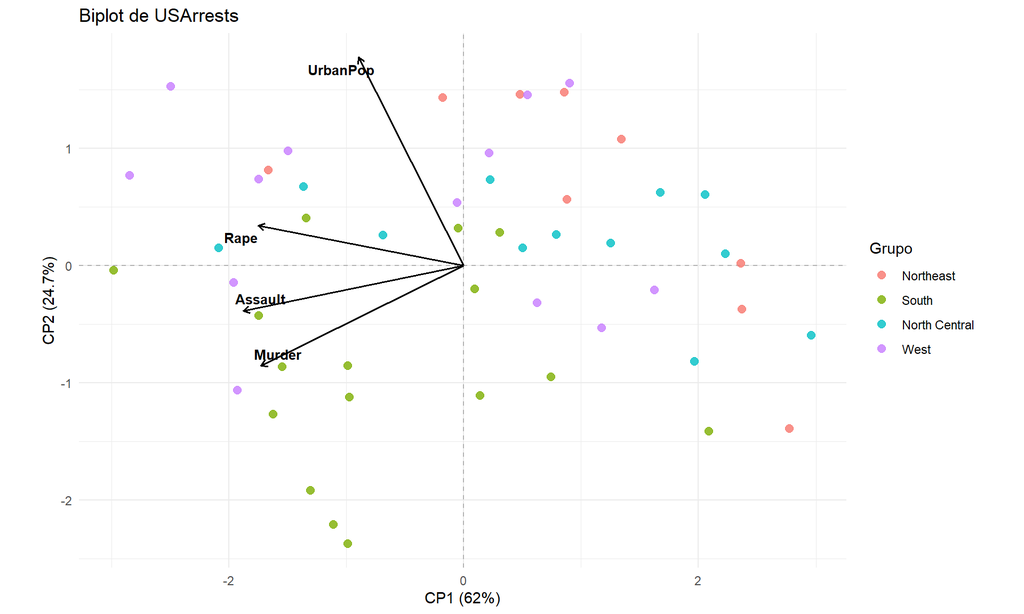

```r
# Construye un Biplot coloreando los estados según su región.
grafico_us <- crear_biplot_correlacion(
  pca = pca_us,
  grupo = regiones,
  titulo = "Biplot de USArrests"
)

# Muestra el Biplot.
print(grafico_us)
```

### Análisis guiado de `USArrests`

CP1 y CP2 conservan 86.8% de la variabilidad. La variable más asociada en valor absoluto con CP1 es **Assault** y con CP2 es **UrbanPop**. La interpretación debe distinguir entre una dimensión general de tasas delictivas y cualquier dimensión diferente asociada con urbanización u otro patrón que emerja de las cargas.

Los colores regionales son información suplementaria: **la región no intervino en el cálculo del ACP**. Si algunas regiones parecen agruparse, se trata de una estructura observada a posteriori. No debe afirmarse que el ACP “encontró” las regiones ni que las diferencias son causalmente geográficas.

> **Preguntas para resolver.** ¿Qué variables delictivas apuntan en direcciones similares? ¿`UrbanPop` se comporta como ellas o define otra dimensión? ¿Observa regiones con fuerte superposición? ¿Qué conclusión sería demasiado fuerte a partir del gráfico solamente?

# 12 11. Errores y malas prácticas que esta versión evita

1. No se ejecuta `install.packages()` durante la práctica.
2. No se cargan paquetes que después no se utilizan.
3. No se recalcula el mismo ACP varias veces con nombres genéricos que sobrescriben objetos anteriores.
4. Se utiliza una única muestra analítica de `Cars93` y se informa cuántas filas se excluyeron.
5. No se confunden los coeficientes de `rotation` con porcentajes de contribución.
6. Se diferencia explícitamente entre rotaciones, correlaciones variable-componente y contribuciones.
7. Se justifica el uso de `scale. = TRUE`.
8. Se incluye un scree plot y criterios de retención antes de interpretar sólo dos componentes.
9. Se utiliza una única definición coherente de Biplot de correlación para los ejemplos gráficos.
10. El factor usado para agrandar las flechas se declara como **puramente visual**.
11. Las elipses se presentan como resúmenes descriptivos y no como fronteras de clasificación.
12. Se evita interpretar el signo de una componente como si fuera absoluto.
13. Las etiquetas se gestionan con `ggrepel` para reducir solapamientos.
14. Se evita producir automáticamente decenas de diagramas redundantes por todas las combinaciones de variables.
15. No se eliminan observaciones sólo porque aparezcan como valores atípicos en un boxplot.

# 13 12. Reto integrador: preguntas para entregar

Las preguntas anteriores acompañan cada etapa. Para cerrar la práctica, responda además las siguientes preguntas utilizando **resultados numéricos y evidencia gráfica** del documento.

1. Redacte un perfil exploratorio de `Cars93` en un máximo de 200 palabras que incluya composición categórica, dos características de las distribuciones numéricas y dos asociaciones relevantes.
2. Seleccione un par de variables con correlación positiva fuerte y otro con correlación negativa fuerte. Explique si la geometría del Biplot reproduce esas relaciones y por qué.
3. Proponga un nombre interpretativo para CP1 y CP2. Para cada nombre cite al menos tres correlaciones variable–componente y no sólo los coeficientes de `rotation`.
4. Compare los criterios de Kaiser, 80% acumulado y scree plot. Defienda cuántas componentes conservaría para descripción numérica y cuántas utilizaría para visualización.
5. Identifique dos automóviles extremos en el plano y explique su posición a partir de las flechas. Evite utilizar la palabra “atípico” sin justificar qué significa en este contexto.
6. Compare dos tipos de automóvil con centroides alejados. ¿Las cajas por tipo respaldan la misma historia que el Biplot?
7. Seleccione la variable peor representada en CP1–CP2. Explique por qué cualquier interpretación de su flecha debe ser prudente y qué análisis adicional realizaría.
8. Compare `Cars93`, `iris` y `USArrests`: ¿en cuál resulta más convincente una representación bidimensional? Fundamente con varianza explicada y estructura visual, no sólo con preferencias estéticas.
9. Escriba tres afirmaciones que **sí** están respaldadas por el Biplot de `Cars93` y tres afirmaciones que serían excesivas o incorrectas.
10. Formule una nueva pregunta de investigación que pueda explorarse con estas bases y describa qué salida de R utilizaría para comenzar a responderla.

# 14 13. Referencias

- R `stats`, documentación de `prcomp`: https://stat.ethz.ch/R-manual/R-devel/library/stats/html/prcomp.html
- R `stats`, documentación de Biplot para componentes principales: https://stat.ethz.ch/R-manual/R-devel/library/stats/help/biplot.prcomp.html
- R `MASS`, documentación de `Cars93`: https://stat.ethz.ch/R-manual/R-devel/library/MASS/html/Cars93.html
- Gabriel, K. R. (1971). *The Biplot Graphic Display of Matrices with Application to Principal Component Analysis*. Biometrika, 58(3), 453–467.
- Venables, W. N. y Ripley, B. D. (2002). *Modern Applied Statistics with S*. Springer.

# 15 14. Cierre

El análisis descriptivo, la correlación y el ACP no son procedimientos aislados. La exploración univariada permite conocer cada variable; la correlación identifica redundancias y asociaciones; el ACP reorganiza esa estructura en direcciones ortogonales; y el Biplot permite visualizar simultáneamente observaciones y variables. Su interpretación debe apoyarse siempre en la varianza explicada, las correlaciones variable-componente y la geometría de las flechas, evitando convertir una representación bidimensional en una descripción exacta de toda la estructura multivariada.